# Google Capstone Analysis

Anna Fomina

2024-02-04

# GOOGLE DATA ANALYTICS

## CASE STUDY: How does a bike-share navigate speedy success?

### Introduction

In this case study, I will conduct a descriptive time series data analysis for a fictional bikeshare company, Cyclistic. In order to identify trends and answer the business question, I will follow the 6 steps of data analysis process: **Ask, Prepare, Process, Analyze, Share,** and **Act**.

### Project Description

In 2016, Cyclistic launched a successful bike-share offering. Since then, the program has grown to a fleet of 5,824 bicycles that are geotracked and locked into a network of 692 stations across Chicago. The bikes can be unlocked from one station and returned to any other station in the system anytime.

Until now, Cyclistic’s marketing strategy relied on building general awareness and appealing to broad consumer segments. One approach that helped make these things possible was the flexibility of its pricing plans: single-ride passes, full-day passes, and annual memberships. Customers who purchase single-ride or full-day passes are referred to as casual riders. Customers who purchase annual memberships are Cyclistic members.

Cyclistic’s finance analysts have concluded that annual members are much more profitable than casual riders. Although the pricing flexibility helps Cyclistic attract more customers, the marketing director believes that maximizing the number of annual members will be key to future growth. Therefore, the team wants to understand **How casual riders and annual members use Cyclistic bikes differently**. These insights, will help design a new marketing strategy to convert casual riders into annual members.

## 1. ASK

### Bussiness question

How do annual members and casual riders use Cyclistic bikes differently?

## 2. PREPARE

### 2.1 Tools

```r
# Setting CRAN mirror to 0-Cloud.
# This line sets the default CRAN mirror to the 0-Cloud mirror, which is located at <https://cran.r-project.org/>.
options(repos = "https://cran.r-project.org/")
```

### 2.2 Installing packages

```r
install.packages("tidyverse")
install.packages('lubridate')
install.packages('janitor')
install.packages("skimr")
```

### 2.3 Loading libraries

```r
library(readr)
library(ggplot2)
library(tidyr)
library(tidyverse)
library(lubridate)
library(janitor)
library(hms)
library(skimr)
```

### 2.4 About data

I am utilizing the 2023 bike trip data records provided by Motivate International Inc. under the terms of [this license agreement](https://divvybikes.com/data-license-agreement). The data is divided into 12 CSV files, each corresponding to a different month.

Data is reliable, original, comprehensive, current, and properly cited. It serves as a valuable tool for gaining insights into variations in customer behavior and for pinpointing trends crucial for crafting effective marketing strategies.

### 2.5 Loading CSV files

Using the *read.csv()* function to open CSV files and save them as a data frames with a descriptive name.

```r
jan_2023_bike_data = read.csv("C:\\Users\\annfo\\OneDrive\\Desktop\\GDA capstone project\\divvy-tripdata\\202301-divvy-tripdata.csv")
feb_2023_bike_data = read.csv("C:\\Users\\annfo\\OneDrive\\Desktop\\GDA capstone project\\divvy-tripdata\\202302-divvy-tripdata.csv")
mar_2023_bike_data = read.csv("C:\\Users\\annfo\\OneDrive\\Desktop\\GDA capstone project\\divvy-tripdata\\202303-divvy-tripdata.csv")
apr_2023_bike_data = read.csv("C:\\Users\\annfo\\OneDrive\\Desktop\\GDA capstone project\\divvy-tripdata\\202304-divvy-tripdata.csv")
mai_2023_bike_data = read.csv("C:\\Users\\annfo\\OneDrive\\Desktop\\GDA capstone project\\divvy-tripdata\\202305-divvy-tripdata.csv")
jun_2023_bike_data = read.csv("C:\\Users\\annfo\\OneDrive\\Desktop\\GDA capstone project\\divvy-tripdata\\202306-divvy-tripdata.csv")
jul_2023_bike_data = read.csv("C:\\Users\\annfo\\OneDrive\\Desktop\\GDA capstone project\\divvy-tripdata\\202307-divvy-tripdata.csv")
aug_2023_bike_data = read.csv("C:\\Users\\annfo\\OneDrive\\Desktop\\GDA capstone project\\divvy-tripdata\\202308-divvy-tripdata.csv")
sep_2023_bike_data = read.csv("C:\\Users\\annfo\\OneDrive\\Desktop\\GDA capstone project\\divvy-tripdata\\202309-divvy-tripdata.csv")
oct_2023_bike_data = read.csv("C:\\Users\\annfo\\OneDrive\\Desktop\\GDA capstone project\\divvy-tripdata\\202310-divvy-tripdata.csv")
nov_2023_bike_data = read.csv("C:\\Users\\annfo\\OneDrive\\Desktop\\GDA capstone project\\divvy-tripdata\\202311-divvy-tripdata.csv")
dec_2023_bike_data = read.csv("C:\\Users\\annfo\\OneDrive\\Desktop\\GDA capstone project\\divvy-tripdata\\202312-divvy-tripdata.csv")
```

Each file contains 13 columns: ride_id, rideable_type, started_at, ended_at, start_station_name, start_station_id, end_station_name, end_station_id, start_lat, start_lng, end_lat, end_lng, and member_casual. All columns are formatted as strings, except for those describing the ride start/end location (start_lat, start_lng, end_lat, end_lng), which are represented as numerical values. Here’s a quick overview of the metadata for the January dataset:

```r
str(jan_2023_bike_data)
```

```
## 'data.frame':    190301 obs. of  13 variables:
##  $ ride_id           : chr  "F96D5A74A3E41399" "13CB7EB698CEDB88" "BD88A2E670661CE5" "C90792D034FED968" ...
##  $ rideable_type     : chr  "electric_bike" "classic_bike" "electric_bike" "classic_bike" ...
##  $ started_at        : chr  "2023-01-21 20:05:42" "2023-01-10 15:37:36" "2023-01-02 07:51:57" "2023-01-22 10:52:58" ...
##  $ ended_at          : chr  "2023-01-21 20:16:33" "2023-01-10 15:46:05" "2023-01-02 08:05:11" "2023-01-22 11:01:44" ...
##  $ start_station_name: chr  "Lincoln Ave & Fullerton Ave" "Kimbark Ave & 53rd St" "Western Ave & Lunt Ave" "Kimbark Ave & 53rd St" ...
##  $ start_station_id  : chr  "TA1309000058" "TA1309000037" "RP-005" "TA1309000037" ...
##  $ end_station_name  : chr  "Hampden Ct & Diversey Ave" "Greenwood Ave & 47th St" "Valli Produce - Evanston Plaza" "Greenwood Ave & 47th St" ...
##  $ end_station_id    : chr  "202480.0" "TA1308000002" "599" "TA1308000002" ...
##  $ start_lat         : num  41.9 41.8 42 41.8 41.8 ...
##  $ start_lng         : num  -87.6 -87.6 -87.7 -87.6 -87.6 ...
##  $ end_lat           : num  41.9 41.8 42 41.8 41.8 ...
##  $ end_lng           : num  -87.6 -87.6 -87.7 -87.6 -87.6 ...
##  $ member_casual     : chr  "member" "member" "casual" "member" ...
```

```r
colnames(jan_2023_bike_data)
```

```
##  [1] "ride_id"            "rideable_type"      "started_at"
##  [4] "ended_at"           "start_station_name" "start_station_id"
##  [7] "end_station_name"   "end_station_id"     "start_lat"
## [10] "start_lng"          "end_lat"            "end_lng"
## [13] "member_casual"
```

## 3. PROCESS

### 3.1 Merging monthly data into one data frame *bike_data_2023*

Total observation count: 5 719 877

```r
bike_data_2023 <- rbind(jan_2023_bike_data, feb_2023_bike_data, mar_2023_bike_data, apr_2023_bike_data, mai_2023_bike_data, jun_2023_bike_data, jul_2023_bike_data, aug_2023_bike_data, sep_2023_bike_data, oct_2023_bike_data, nov_2023_bike_data, dec_2023_bike_data)
```

Reviewing new data frame:

```r
#Number of row
nrow(bike_data_2023)
```

```
## [1] 5719877
```

```r
#Number of columns
ncol(bike_data_2023)
```

```
## [1] 13
```

```r
#First few rows of bike_data_2023 dataset, column names, data types
glimpse(bike_data_2023)
```

```
## Rows: 5,719,877
## Columns: 13
## $ ride_id            <chr> "F96D5A74A3E41399", "13CB7EB698CEDB88", "BD88A2E670…
## $ rideable_type      <chr> "electric_bike", "classic_bike", "electric_bike", "…
## $ started_at         <chr> "2023-01-21 20:05:42", "2023-01-10 15:37:36", "2023…
## $ ended_at           <chr> "2023-01-21 20:16:33", "2023-01-10 15:46:05", "2023…
## $ start_station_name <chr> "Lincoln Ave & Fullerton Ave", "Kimbark Ave & 53rd …
## $ start_station_id   <chr> "TA1309000058", "TA1309000037", "RP-005", "TA130900…
## $ end_station_name   <chr> "Hampden Ct & Diversey Ave", "Greenwood Ave & 47th …
## $ end_station_id     <chr> "202480.0", "TA1308000002", "599", "TA1308000002", …
## $ start_lat          <dbl> 41.92407, 41.79957, 42.00857, 41.79957, 41.79957, 4…
## $ start_lng          <dbl> -87.64628, -87.59475, -87.69048, -87.59475, -87.594…
## $ end_lat            <dbl> 41.93000, 41.80983, 42.03974, 41.80983, 41.80983, 4…
## $ end_lng            <dbl> -87.64000, -87.59938, -87.69941, -87.59938, -87.599…
## $ member_casual      <chr> "member", "member", "casual", "member", "member", "…
```

```r
#Structure of bike_data_2023 dataset, data types, first few values of each variable
str(bike_data_2023)
```

```
## 'data.frame':    5719877 obs. of  13 variables:
##  $ ride_id           : chr  "F96D5A74A3E41399" "13CB7EB698CEDB88" "BD88A2E670661CE5" "C90792D034FED968" ...
##  $ rideable_type     : chr  "electric_bike" "classic_bike" "electric_bike" "classic_bike" ...
##  $ started_at        : chr  "2023-01-21 20:05:42" "2023-01-10 15:37:36" "2023-01-02 07:51:57" "2023-01-22 10:52:58" ...
##  $ ended_at          : chr  "2023-01-21 20:16:33" "2023-01-10 15:46:05" "2023-01-02 08:05:11" "2023-01-22 11:01:44" ...
##  $ start_station_name: chr  "Lincoln Ave & Fullerton Ave" "Kimbark Ave & 53rd St" "Western Ave & Lunt Ave" "Kimbark Ave & 53rd St" ...
##  $ start_station_id  : chr  "TA1309000058" "TA1309000037" "RP-005" "TA1309000037" ...
##  $ end_station_name  : chr  "Hampden Ct & Diversey Ave" "Greenwood Ave & 47th St" "Valli Produce - Evanston Plaza" "Greenwood Ave & 47th St" ...
##  $ end_station_id    : chr  "202480.0" "TA1308000002" "599" "TA1308000002" ...
##  $ start_lat         : num  41.9 41.8 42 41.8 41.8 ...
##  $ start_lng         : num  -87.6 -87.6 -87.7 -87.6 -87.6 ...
##  $ end_lat           : num  41.9 41.8 42 41.8 41.8 ...
##  $ end_lng           : num  -87.6 -87.6 -87.7 -87.6 -87.6 ...
##  $ member_casual     : chr  "member" "member" "casual" "member" ...
```

NA values in end_lat and end_lng

```r
#Statistical summary of the variables in bike_data_2023 dataset
summary(bike_data_2023)
```

```
##    ride_id          rideable_type       started_at          ended_at
##  Length:5719877     Length:5719877     Length:5719877     Length:5719877
##  Class :character   Class :character   Class :character   Class :character
##  Mode  :character   Mode  :character   Mode  :character   Mode  :character
##
##
##
##
##  start_station_name start_station_id   end_station_name   end_station_id
##  Length:5719877     Length:5719877     Length:5719877     Length:5719877
##  Class :character   Class :character   Class :character   Class :character
##  Mode  :character   Mode  :character   Mode  :character   Mode  :character
##
##
##
##
##    start_lat       start_lng         end_lat         end_lng
##  Min.   :41.63   Min.   :-87.94   Min.   : 0.00   Min.   :-88.16
##  1st Qu.:41.88   1st Qu.:-87.66   1st Qu.:41.88   1st Qu.:-87.66
##  Median :41.90   Median :-87.64   Median :41.90   Median :-87.64
##  Mean   :41.90   Mean   :-87.65   Mean   :41.90   Mean   :-87.65
##  3rd Qu.:41.93   3rd Qu.:-87.63   3rd Qu.:41.93   3rd Qu.:-87.63
##  Max.   :42.07   Max.   :-87.46   Max.   :42.18   Max.   :  0.00
##                                   NA's   :6990    NA's   :6990
##  member_casual
##  Length:5719877
##  Class :character
##  Mode  :character
##
##
##
##
```

First and last rows.

```r
#First
head(bike_data_2023)
```

```
##            ride_id rideable_type          started_at            ended_at
## 1 F96D5A74A3E41399 electric_bike 2023-01-21 20:05:42 2023-01-21 20:16:33
## 2 13CB7EB698CEDB88  classic_bike 2023-01-10 15:37:36 2023-01-10 15:46:05
## 3 BD88A2E670661CE5 electric_bike 2023-01-02 07:51:57 2023-01-02 08:05:11
## 4 C90792D034FED968  classic_bike 2023-01-22 10:52:58 2023-01-22 11:01:44
## 5 3397017529188E8A  classic_bike 2023-01-12 13:58:01 2023-01-12 14:13:20
## 6 58E68156DAE3E311 electric_bike 2023-01-31 07:18:03 2023-01-31 07:21:16
##              start_station_name start_station_id               end_station_name
## 1   Lincoln Ave & Fullerton Ave     TA1309000058      Hampden Ct & Diversey Ave
## 2         Kimbark Ave & 53rd St     TA1309000037        Greenwood Ave & 47th St
## 3        Western Ave & Lunt Ave           RP-005 Valli Produce - Evanston Plaza
## 4         Kimbark Ave & 53rd St     TA1309000037        Greenwood Ave & 47th St
## 5         Kimbark Ave & 53rd St     TA1309000037        Greenwood Ave & 47th St
## 6 Lakeview Ave & Fullerton Pkwy     TA1309000019      Hampden Ct & Diversey Ave
##   end_station_id start_lat start_lng  end_lat   end_lng member_casual
## 1       202480.0  41.92407 -87.64628 41.93000 -87.64000        member
## 2   TA1308000002  41.79957 -87.59475 41.80983 -87.59938        member
## 3            599  42.00857 -87.69048 42.03974 -87.69941        casual
## 4   TA1308000002  41.79957 -87.59475 41.80983 -87.59938        member
## 5   TA1308000002  41.79957 -87.59475 41.80983 -87.59938        member
## 6       202480.0  41.92607 -87.63886 41.93000 -87.64000        member
```

```r
#Last
tail(bike_data_2023)
```

```
##                  ride_id rideable_type          started_at            ended_at
## 5719872 AB675DD0012CBD57 electric_bike 2023-12-04 23:34:11 2023-12-04 23:39:16
## 5719873 F74DF9549B504A6B electric_bike 2023-12-07 13:15:24 2023-12-07 13:17:37
## 5719874 BCDA66E761CC1029  classic_bike 2023-12-08 18:42:21 2023-12-08 18:45:56
## 5719875 D2CF330F9C266683  classic_bike 2023-12-05 14:09:11 2023-12-05 14:13:01
## 5719876 3829A0D1E00EE970 electric_bike 2023-12-02 21:36:07 2023-12-02 21:53:45
## 5719877 A373F5B447AEA508  classic_bike 2023-12-11 13:07:46 2023-12-11 13:11:24
##             start_station_name start_station_id           end_station_name
## 5719872   Racine Ave & 18th St            13164 Racine Ave & Congress Pkwy
## 5719873      900 W Harrison St            13028 Racine Ave & Congress Pkwy
## 5719874      900 W Harrison St            13028 Racine Ave & Congress Pkwy
## 5719875      900 W Harrison St            13028 Racine Ave & Congress Pkwy
## 5719876 Damen Ave & Madison St            13134       Morgan St & Lake St*
## 5719877      900 W Harrison St            13028 Racine Ave & Congress Pkwy
##         end_station_id start_lat start_lng  end_lat   end_lng member_casual
## 5719872   TA1306000025  41.85824 -87.65638 41.87464 -87.65703        member
## 5719873   TA1306000025  41.87470 -87.64980 41.87464 -87.65703        casual
## 5719874   TA1306000025  41.87475 -87.64981 41.87464 -87.65703        casual
## 5719875   TA1306000025  41.87475 -87.64981 41.87464 -87.65703        member
## 5719876   chargingstx4  41.88140 -87.67498 41.88549 -87.65229        casual
## 5719877   TA1306000025  41.87475 -87.64981 41.87464 -87.65703        member
```

No duplicates in ride_id all rows in data frame have a unique IDs. Some rows are missing start/end station data. 6990 have NA values in end_lat, end_lng.

```r
#Statistical summary, data types, missing values, quantiles for numerical variables, frequency counts for categorical variables
skim_without_charts(bike_data_2023)
```

Data summary

| Name | bike_data_2023 |
| --- | --- |
| Number of rows | 5719877 |
| Number of columns | 13 |
| _______________________ |  |
| Column type frequency: |  |
| character | 9 |
| numeric | 4 |
| ________________________ |  |
| Group variables | None |

**Variable type: character**

| skim_variable | n_missing | complete_rate | min | max | empty | n_unique | whitespace |
| --- | --- | --- | --- | --- | --- | --- | --- |
| ride_id | 0 | 1 | 16 | 16 | 0 | 5719877 | 0 |
| rideable_type | 0 | 1 | 11 | 13 | 0 | 3 | 0 |
| started_at | 0 | 1 | 19 | 19 | 0 | 4823909 | 0 |
| ended_at | 0 | 1 | 19 | 19 | 0 | 4835702 | 0 |
| start_station_name | 0 | 1 | 0 | 64 | 875716 | 1593 | 0 |
| start_station_id | 0 | 1 | 0 | 35 | 875848 | 1517 | 0 |
| end_station_name | 0 | 1 | 0 | 64 | 929202 | 1598 | 0 |
| end_station_id | 0 | 1 | 0 | 36 | 929343 | 1521 | 0 |
| member_casual | 0 | 1 | 6 | 6 | 0 | 2 | 0 |

**Variable type: numeric**

| skim_variable | n_missing | complete_rate | mean | sd | p0 | p25 | p50 | p75 | p100 |
| --- | --- | --- | --- | --- | --- | --- | --- | --- | --- |
| start_lat | 0 | 1 | 41.90 | 0.05 | 41.63 | 41.88 | 41.90 | 41.93 | 42.07 |
| start_lng | 0 | 1 | -87.65 | 0.03 | -87.94 | -87.66 | -87.64 | -87.63 | -87.46 |
| end_lat | 6990 | 1 | 41.90 | 0.05 | 0.00 | 41.88 | 41.90 | 41.93 | 42.18 |
| end_lng | 6990 | 1 | -87.65 | 0.07 | -88.16 | -87.66 | -87.64 | -87.63 | 0.00 |

### 3.2 Data cleaning: Formating data and creating additional colums for future calculations and agregation

#### 3.2.1 Changing strings in *started_at* and *ended_at* columns to DATE-TIME format

Using the *ymd_hms()* funcion of lubridate package.

```r
bike_data_2023$started_at <- ymd_hms(bike_data_2023$started_at)
bike_data_2023$ended_at <- ymd_hms(bike_data_2023$ended_at)
```

#### 3.2.2 Calculating *ride lengths*

Saving calculated ride duration into *ride_length* column and updating the *ride_data_2023* dataframe. Results are in seconds.

```r
bike_data_2023 <- bike_data_2023 %>%
  mutate(ride_length = as.numeric(ended_at - started_at))
```

#### 3.2.3 Creating column to store the *month* when rides took place

```r
bike_data_2023 <- bike_data_2023 %>%
  mutate(month = month(started_at, label = TRUE, abbr = FALSE)) #Getting month names

#Ordering months Jan, Feb, ... , Dec
bike_data_2023$month <- factor(bike_data_2023$month, levels = month.name, ordered = TRUE)
```

#### 3.2.4 Creating column to store the *day* when rides took place

wday() function returns numbers for each week day where 1 = Sunday … 7 = Saturday. Storing *weekday names* in separate column for quick reference.

```r
bike_data_2023 <- bike_data_2023 %>%
  mutate(day_of_week_numeric = wday(started_at),
         day_of_week = factor(weekdays(started_at), levels = c("Sunday", "Monday", "Tuesday", "Wednesday", "Thursday", "Friday", "Saturday")))
```

#### 3.2.4 Filtering out *workdays* and *weekends*.

```r
#Workdays vs weekends, new column
bike_data_2023 <- bike_data_2023 %>%
  mutate(workday_weekend = ifelse(weekdays(started_at) %in% c("Saturday", "Sunday"), "Weekend", "Workday"))
```

#### 3.2.5 Creating column to store the *time* when rides took place. (24h format)

For my analisys I will group data by hour, dropping minutes.

```r
#Hour at which rides started.
bike_data_2023 <- bike_data_2023 %>%
  mutate(start_hour = hour(started_at))
```

### 3.3 Station data

#### 3.3.1 Attempting to recover station names and IDs

I will try to retrieve station data, recognizing that while some rows may lack start/end station names and IDs, the majority still contain latitude and longitude data. To achieve this goal, I will look at combinations of minimum and maximum values in latitude and longitude within rows possessing complete ride information and seek out similar coordinates in rows where start station names and IDs are absent. This process will involve both the “raw” and rounded latitude/longitude data. Given that my analysis primarily focuses on differences in ride length and ride count between two customer types, this step will play a part in identifying the most popular stations.

```r
bike_data_2023$start_lat <- as.numeric(bike_data_2023$start_lat)
bike_data_2023$start_lng <- as.numeric(bike_data_2023$start_lng)
bike_data_2023$end_lat <- as.numeric(bike_data_2023$end_lat)
bike_data_2023$end_lng <- as.numeric(bike_data_2023$end_lng)

bike_data_2023 <- bike_data_2023 %>%
  mutate(start_lat_round = as.numeric(round(start_lat, digits = 2)),
        start_lng_round = as.numeric(round(start_lng, digits = 2)),
        end_lat_round = as.numeric(round(end_lat, digits = 2)),
        end_lng_round = as.numeric(round(end_lng, digits = 2)))
```

#### 3.3.3 Generating tables containing complete station data for filling in missing fields in bike_data_2023

```r
#Creating table for Start Station lat/lng values
start_station_info <- bike_data_2023 %>%
  filter(!is.na(start_station_name) & start_station_name != "" &
         !is.na(start_station_id) & start_station_id != "") %>%
  mutate(
    start_lat = as.numeric(start_lat),
    start_lng = as.numeric(start_lng)
  ) %>%
  group_by(station_name = start_station_name, station_id = start_station_id, .groups = "drop") %>%
  summarize(
    min_lat = min(start_lat, na.rm = TRUE),
    max_lat = max(start_lat, na.rm = TRUE),
    min_lng = min(start_lng, na.rm = TRUE),
    max_lng = max(start_lng, na.rm = TRUE)
  ) %>%
  mutate(
    rounded_min_lat = round(min_lat, 2),
    rounded_max_lat = round(max_lat, 2),
    rounded_min_lng = round(min_lng, 2),
    rounded_max_lng = round(max_lng, 2)
  ) %>%
  ungroup()
#Creating table for End Station lat/lng values
end_station_info <- bike_data_2023 %>%
  filter(!is.na(end_station_name) & end_station_name != "" &
         !is.na(end_station_id) & end_station_id != "") %>%
  mutate(
    end_lat = as.numeric(end_lat),
    end_lng = as.numeric(end_lng)
  ) %>%
  group_by(station_name = end_station_name, station_id = end_station_id, .groups = "drop") %>%
  summarize(
    min_lat = min(end_lat, na.rm = TRUE),
    max_lat = max(end_lat, na.rm = TRUE),
    min_lng = min(end_lng, na.rm = TRUE),
    max_lng = max(end_lng, na.rm = TRUE)
  ) %>%
  mutate(
    rounded_min_lat = round(min_lat, 2),
    rounded_max_lat = round(max_lat, 2),
    rounded_min_lng = round(min_lng, 2),
    rounded_max_lng = round(max_lng, 2)
  ) %>%
  ungroup()
```

#### 3.3.4 Creating function for generating conditions

The function will generate conditions of **min ≤ value ≤ max** for latitude and longitude values from two dataframes. A slight tolerance is added to expand the value range for consideration.

```r
#Adding tolerance
tolerance <- 0.002

#Creating function
generate_condition <- function(data,
                               station_name_column,
                               station_id_column,
                               lat_column,
                               lng_column,
                               round_lat_column,
                               round_lng_column,
                               station_info) {
  condition <- data[[station_name_column]] == "" & data[[station_id_column]] == "" &
    (
      data[[lat_column]] >= station_info$min_lat - tolerance &
      data[[lat_column]] <= station_info$max_lat + tolerance &
      data[[lng_column]] >= station_info$min_lng - tolerance &
      data[[lng_column]] <= station_info$max_lng + tolerance
    ) |
    (
      data[[round_lat_column]] >= station_info$rounded_min_lat &
      data[[round_lat_column]] <= station_info$rounded_max_lat &
      data[[round_lng_column]] >= station_info$rounded_min_lng &
      data[[round_lng_column]] <= station_info$rounded_max_lng
    )

  return(condition)
}
```

#### 3.3.5 Generating conitions to fill in empty cells

```r
#Generate conditions for Start stations using Start station info
condition_start <- generate_condition(
  bike_data_2023,
  "start_station_name",
  "start_station_id",
  "start_lat",
  "start_lng",
  "start_lat_round",
  "start_lng_round",
  start_station_info
)
#Generate conditions for End stations using End station info
condition_end <- generate_condition(
  bike_data_2023,
  "end_station_name",
  "end_station_id",
  "end_lat",
  "end_lng",
  "end_lat_round",
  "end_lat_round",
  end_station_info
)
```

#### 3.3.6 Applying the same principles, I am utilizing Start station data to restore End stations and vice versa

```r
#Generate conditions for Start stations using End Station info
condition_start_from_end <- generate_condition(
  bike_data_2023,
  "start_station_name",
  "start_station_id",
  "start_lat",
  "start_lng",
  "start_lat_round",
  "start_lng_round",
  end_station_info
)
#Generate conditions for End Stations using start Station info
condition_end_from_start <- generate_condition(
  bike_data_2023,
  "end_station_name",
  "end_station_id",
  "end_lat",
  "end_lng",
  "end_lat_round",
  "end_lat_round",
  start_station_info
)
```

#### 3.3.7 Adding station data to the duplicated dataframe for later review of changes

```r
#Updating bike_data_2023 Start Stations & End Stations
bike_data_2023_2 <- bike_data_2023 %>%
  mutate(
    start_station_name = ifelse(condition_start, start_station_info$station_name, start_station_name),
    start_station_id = ifelse(condition_start, start_station_info$station_id, start_station_id),
    end_station_name = ifelse(condition_end, end_station_info$station_name, end_station_name),
    end_station_id = ifelse(condition_end, end_station_info$station_id, end_station_id),

    start_station_name = ifelse(condition_start_from_end, end_station_info$station_name, start_station_name),
    start_station_id = ifelse(condition_start_from_end, end_station_info$station_id, start_station_id),
    end_station_name = ifelse(condition_end_from_start, start_station_info$station_name, end_station_name),
    end_station_id = ifelse(condition_end_from_start, start_station_info$station_id, end_station_id)
  )
```

#### 3.3.8 Reviewing changes in data

```r
#Comparing to unaltered Start stations
#bike_data_2023 %>%
  #filter(start_station_name == "" & start_station_id == "")

#bike_data_2023_2 %>%
  #filter(start_station_name == "" & start_station_id == "")

#Comparing to unaltered End stations
#bike_data_2023 %>%
  #filter(end_station_name == "" & end_station_id == "")

#bike_data_2023_2 %>%
  #filter(end_station_name == "" & end_station_id == "")
```

Review: Total nr of values restored for Start Stations: 77 463 Total nr of values restored for End Stations: 76 937

#### 3.3.9 Updating original data frame *bike_data_2023*

```r
bike_data_2023 <- bike_data_2023_2
```

#### 3.3.10 Bike maintenance station names and IDs

To maintain the integrity of analysis, rides to and from stations designated for storing, repairing, testing, or charging bikes are filtered out and removed.

```r
#Start Stations
check_start_station <- bike_data_2023 %>%
  distinct(station_name = start_station_name, station_id = start_station_id)
#print(check_start_station)

#Bike service stops Start stations
check_test_start_station <- bike_data_2023 %>%
   filter(
    grepl("test", start_station_id, ignore.case = TRUE) |
    grepl("test", start_station_name, ignore.case = TRUE) |
    grepl("warehouse", start_station_id, ignore.case = TRUE) |
    grepl("warehouse", start_station_name, ignore.case = TRUE) |
    grepl("divvy", start_station_id, ignore.case = TRUE) |
    grepl("divvy", start_station_name, ignore.case = TRUE) |
    grepl("charging", start_station_id, ignore.case = TRUE) |
    grepl("charging", start_station_name, ignore.case = TRUE)
  ) %>%
  count(start_station_name, start_station_id)
#print(check_test_start_station)

#End Stations
check_end_station <- bike_data_2023 %>%
  distinct(station_name = end_station_name, station_id = end_station_id)
#print(check_end_station)

#Bike service stops End stations
check_test_end_station <- bike_data_2023 %>%
  filter(
    grepl("test", end_station_id, ignore.case = TRUE) |
    grepl("test", end_station_name, ignore.case = TRUE) |
    grepl("warehouse", end_station_id, ignore.case = TRUE) |
    grepl("warehouse", end_station_name, ignore.case = TRUE) |
    grepl("divvy", end_station_id, ignore.case = TRUE) |
    grepl("divvy", end_station_name, ignore.case = TRUE) |
    grepl("charging", end_station_id, ignore.case = TRUE) |
    grepl("charging", end_station_name, ignore.case = TRUE)
  ) %>%
  count(end_station_name, end_station_id)
#print(check_test_end_station)
```

### 3.4 Removing insufficient data

#### 3.4.1 Removing maintenance rides

```r
#Deleting rides that started from service station
bike_data_2023 <- subset(bike_data_2023, !(start_station_name %in% check_test_start_station$start_station_name))

#Deleting rides that ended at service station
bike_data_2023 <- subset(bike_data_2023, !(end_station_name %in% check_test_end_station$end_station_name))
```

#### 3.4.2 Removing rides where all 4 columns are NA (NA only in end stations)

```r
bike_data_2023_2 <- subset(bike_data_2023_2, !(is.na(end_lat) & is.na(end_lng) & end_station_name == "" & end_station_id == ""))
```

#### 3.4.3 Removing rides that are less than 1 minute (60 seconds) and longer than one day (86400 seconds).

At the beginning, it’s been made clear that rides shouldn’t surpass 24 hours. Any entries with timestamps exceeding this limit are considered errors and aren’t suitable for analyzing. Additionally, rides lasting less than a minute will also be excluded from the analysis, as they’re likely to be due to human error.

```r
bike_data_2023 <- subset(bike_data_2023, ride_length >= 60 & ride_length <= 86400)
```

## 4. ANALYZE

### 4.1 Average ride length

#### 4.1.1 Average ride length by month, weekday, and customer type

```r
#Average ride length by month, weekday, and customer type
bike_avg_ride_length <- bike_data_2023 %>%
  group_by(month, day_of_week, member_casual) %>%
  summarize(avg_ride_length = round(mean(ride_length)), .groups = "drop")

print(bike_avg_ride_length)
```

```
## # A tibble: 168 × 4
##    month   day_of_week member_casual avg_ride_length
##    <ord>   <fct>       <chr>                   <dbl>
##  1 January Sunday      casual                   1124
##  2 January Sunday      member                    703
##  3 January Monday      casual                    809
##  4 January Monday      member                    609
##  5 January Tuesday     casual                    767
##  6 January Tuesday     member                    616
##  7 January Wednesday   casual                    797
##  8 January Wednesday   member                    610
##  9 January Thursday    casual                    691
## 10 January Thursday    member                    596
## # ℹ 158 more rows
```

#### 4.1.2 Average ride length by month and customer type

```r
#Average ride length by month and customer type
bike_avg_ride_length_month <- bike_data_2023 %>%
  group_by(month, member_casual) %>%
  summarize(avg_ride_length_month = round(mean(ride_length)), .groups = "drop")

#Converting seconds to MM:SS for chart
bike_avg_ride_length_month$ride_length_min_sec <- sprintf("%02d:%02d",
                                              bike_avg_ride_length_month$avg_ride_length_month %/% 60,
                                              bike_avg_ride_length_month$avg_ride_length_month %% 60)
print(bike_avg_ride_length_month)
```

```
## # A tibble: 24 × 4
##    month    member_casual avg_ride_length_month ride_length_min_sec
##    <ord>    <chr>                         <dbl> <chr>
##  1 January  casual                          848 14:08
##  2 January  member                          624 10:24
##  3 February casual                          982 16:22
##  4 February member                          649 10:49
##  5 March    casual                          947 15:47
##  6 March    member                          631 10:31
##  7 April    casual                         1285 21:25
##  8 April    member                          712 11:52
##  9 May      casual                         1370 22:50
## 10 May      member                          776 12:56
## # ℹ 14 more rows
```

#### 4.1.3 Average ride length by weekday and customer type

```r
#Average ride length by weekday and customer type
bike_avg_ride_length_week <- bike_data_2023 %>%
  group_by(day_of_week, member_casual) %>%
  summarize(avg_ride_length_week = round(mean(ride_length)), .groups = "drop")

#print(bike_avg_ride_length_week)
```

#### 4.1.4 Average ride length by customer type

```r
#Average ride length by customer type
bike_avg_ride_length_member_type <- bike_data_2023 %>%
  group_by(member_casual) %>%
  summarize(avg_ride_length_member_type = round(mean(ride_length)))

bike_avg_ride_length_member_type$ride_length_min_sec <- sprintf("%02d:%02d",
                                              bike_avg_ride_length_member_type$avg_ride_length_member_type %/% 60,
                                              bike_avg_ride_length_member_type$avg_ride_length_member_type %% 60)

print(bike_avg_ride_length_member_type)
```

```
## # A tibble: 2 × 3
##   member_casual avg_ride_length_member_type ride_length_min_sec
##   <chr>                               <dbl> <chr>
## 1 casual                               1274 21:14
## 2 member                                741 12:21
```

#### 4.1.5 Increase in average ride length by customer type

```r
#Calculate the increase in average ride length by customer type
bike_avg_ride_length_month_increase <- bike_avg_ride_length_month %>%
  arrange(month) %>%
  group_by(member_casual) %>%
  mutate(avg_ride_length_previous_month = lag(avg_ride_length_month),
         increase_vs_previous_month = avg_ride_length_month - avg_ride_length_previous_month) %>%
  ungroup()

print(bike_avg_ride_length_month_increase)
```

```
## # A tibble: 24 × 6
##    month    member_casual avg_ride_length_month ride_length_min_sec
##    <ord>    <chr>                         <dbl> <chr>
##  1 January  casual                          848 14:08
##  2 January  member                          624 10:24
##  3 February casual                          982 16:22
##  4 February member                          649 10:49
##  5 March    casual                          947 15:47
##  6 March    member                          631 10:31
##  7 April    casual                         1285 21:25
##  8 April    member                          712 11:52
##  9 May      casual                         1370 22:50
## 10 May      member                          776 12:56
## # ℹ 14 more rows
## # ℹ 2 more variables: avg_ride_length_previous_month <dbl>,
## #   increase_vs_previous_month <dbl>
```

#### 4.1.6 Days with longest and shortest average ride length

```r
sorted_bike_avg_ride_length <- bike_avg_ride_length %>%
  arrange(member_casual, desc(avg_ride_length))

#Days with longest average ride length
max_avg <- sorted_bike_avg_ride_length %>%
  group_by(member_casual) %>%
  slice_max(order_by = avg_ride_length)

#Days with shortest average ride length
min_avg <- sorted_bike_avg_ride_length %>%
  group_by(member_casual) %>%
  slice_min(order_by = avg_ride_length)

max_avg$avg_ride_length_hms <- as_hms(max_avg$avg_ride_length)
min_avg$avg_ride_length_hms <- as_hms(min_avg$avg_ride_length)

print(max_avg)
```

```
## # A tibble: 2 × 5
## # Groups:   member_casual [2]
##   month day_of_week member_casual avg_ride_length avg_ride_length_hms
##   <ord> <fct>       <chr>                   <dbl> <time>
## 1 May   Sunday      casual                   1638 27'18"
## 2 June  Saturday    member                    917 15'17"
```

```r
print(min_avg)
```

```
## # A tibble: 2 × 5
## # Groups:   member_casual [2]
##   month   day_of_week member_casual avg_ride_length avg_ride_length_hms
##   <ord>   <fct>       <chr>                   <dbl> <time>
## 1 January Thursday    casual                    691 11'31"
## 2 January Thursday    member                    596 09'56"
```

```r
print(sorted_bike_avg_ride_length)
```

```
## # A tibble: 168 × 4
##    month     day_of_week member_casual avg_ride_length
##    <ord>     <fct>       <chr>                   <dbl>
##  1 May       Sunday      casual                   1638
##  2 July      Sunday      casual                   1581
##  3 August    Sunday      casual                   1542
##  4 May       Saturday    casual                   1536
##  5 August    Saturday    casual                   1534
##  6 June      Saturday    casual                   1530
##  7 April     Sunday      casual                   1527
##  8 September Sunday      casual                   1515
##  9 July      Saturday    casual                   1506
## 10 June      Sunday      casual                   1489
## # ℹ 158 more rows
```

### 4.2 Ride counts

#### 4.2.1 Ride count by month, weekday, and customer type

```r
#Ride count by month, weekday, and customer type
bike_ride_count <- bike_data_2023 %>%
  group_by(month, day_of_week, member_casual) %>%
  summarize(ride_count = n(), .groups = "drop")

print(bike_ride_count)
```

```
## # A tibble: 168 × 4
##    month   day_of_week member_casual ride_count
##    <ord>   <fct>       <chr>              <int>
##  1 January Sunday      casual              6101
##  2 January Sunday      member             15200
##  3 January Monday      casual              5439
##  4 January Monday      member             21507
##  5 January Tuesday     casual              6614
##  6 January Tuesday     member             28018
##  7 January Wednesday   casual              5739
##  8 January Wednesday   member             23761
##  9 January Thursday    casual              4775
## 10 January Thursday    member             21326
## # ℹ 158 more rows
```

#### 4.2.2 Ride count by month and customer type

```r
#Ride count by month and customer type
bike_ride_count_month <- bike_data_2023 %>%
  group_by(month, member_casual) %>%
  summarize(ride_count_month = n())
print(bike_ride_count_month)
```

```
## # A tibble: 24 × 3
## # Groups:   month [12]
##    month    member_casual ride_count_month
##    <ord>    <chr>                    <int>
##  1 January  casual                   38246
##  2 January  member                  143116
##  3 February casual                   41265
##  4 February member                  140871
##  5 March    casual                   59467
##  6 March    member                  186961
##  7 April    casual                  140483
##  8 April    member                  265330
##  9 May      casual                  224901
## 10 May      member                  356103
## # ℹ 14 more rows
```

##### 4.2.2.1 Top months by ride count and customer type from high to low

```r
#Months by ride count and customer type from high to low
ordered_ride_count_month <- bike_ride_count_month %>%
  arrange(member_casual, desc(ride_count_month))

print(ordered_ride_count_month)
```

```
## # A tibble: 24 × 3
## # Groups:   month [12]
##    month     member_casual ride_count_month
##    <ord>     <chr>                    <int>
##  1 July      casual                  317364
##  2 August    casual                  296971
##  3 June      casual                  288021
##  4 September casual                  250271
##  5 May       casual                  224901
##  6 October   casual                  169324
##  7 April     casual                  140483
##  8 November  casual                   94303
##  9 March     casual                   59467
## 10 December  casual                   49494
## # ℹ 14 more rows
```

```r
#Member
ordered_ride_count_month_member <- ordered_ride_count_month %>%
   filter(member_casual == "member")

print(ordered_ride_count_month_member)
```

```
## # A tibble: 12 × 3
## # Groups:   month [12]
##    month     member_casual ride_count_month
##    <ord>     <chr>                    <int>
##  1 August    member                  441142
##  2 July      member                  419239
##  3 June      member                  401776
##  4 September member                  388841
##  5 May       member                  356103
##  6 October   member                  345895
##  7 April     member                  265330
##  8 November  member                  254098
##  9 March     member                  186961
## 10 December  member                  165313
## 11 January   member                  143116
## 12 February  member                  140871
```

```r
#Casual
ordered_ride_count_month_casual <- ordered_ride_count_month %>%
   filter(member_casual == "casual")

print(ordered_ride_count_month_casual)
```

```
## # A tibble: 12 × 3
## # Groups:   month [12]
##    month     member_casual ride_count_month
##    <ord>     <chr>                    <int>
##  1 July      casual                  317364
##  2 August    casual                  296971
##  3 June      casual                  288021
##  4 September casual                  250271
##  5 May       casual                  224901
##  6 October   casual                  169324
##  7 April     casual                  140483
##  8 November  casual                   94303
##  9 March     casual                   59467
## 10 December  casual                   49494
## 11 February  casual                   41265
## 12 January   casual                   38246
```

#### 4.2.3 Ride count by weekday and customer type

```r
#Ride count by weekday and customer type
bike_ride_count_week <- bike_data_2023 %>%
  group_by(day_of_week, member_casual) %>%
  summarize(ride_count_week = n(), .groups = "drop")

print(bike_ride_count_week)
```

```
## # A tibble: 14 × 3
##    day_of_week member_casual ride_count_week
##    <fct>       <chr>                   <int>
##  1 Sunday      casual                 320498
##  2 Sunday      member                 391485
##  3 Monday      casual                 225075
##  4 Monday      member                 475091
##  5 Tuesday     casual                 235926
##  6 Tuesday     member                 553433
##  7 Wednesday   casual                 238735
##  8 Wednesday   member                 562609
##  9 Thursday    casual                 259067
## 10 Thursday    member                 564693
## 11 Friday      casual                 298460
## 12 Friday      member                 509243
## 13 Saturday    casual                 392349
## 14 Saturday    member                 452131
```

#### 4.2.4 Ride count by hour, wekday and customer type

```r
##Ride count by hour, weekday and customer type
rides_by_hour <- bike_data_2023 %>%
  group_by(member_casual, workday_weekend, start_hour) %>%
  summarise(ride_count = n(), .groups = "drop")

print(bike_ride_count_week)
```

```
## # A tibble: 14 × 3
##    day_of_week member_casual ride_count_week
##    <fct>       <chr>                   <int>
##  1 Sunday      casual                 320498
##  2 Sunday      member                 391485
##  3 Monday      casual                 225075
##  4 Monday      member                 475091
##  5 Tuesday     casual                 235926
##  6 Tuesday     member                 553433
##  7 Wednesday   casual                 238735
##  8 Wednesday   member                 562609
##  9 Thursday    casual                 259067
## 10 Thursday    member                 564693
## 11 Friday      casual                 298460
## 12 Friday      member                 509243
## 13 Saturday    casual                 392349
## 14 Saturday    member                 452131
```

```r
#Filtering out workdays
rides_by_hour_workdays_casual <- filter(rides_by_hour, workday_weekend == "Workday", member_casual == "casual")
rides_by_hour_workdays_member <- filter(rides_by_hour, workday_weekend == "Workday", member_casual == "member")

print(rides_by_hour_workdays_casual)
```

```
## # A tibble: 24 × 4
##    member_casual workday_weekend start_hour ride_count
##    <chr>         <chr>                <int>      <int>
##  1 casual        Workday                  0      14891
##  2 casual        Workday                  1       8738
##  3 casual        Workday                  2       5127
##  4 casual        Workday                  3       3251
##  5 casual        Workday                  4       3171
##  6 casual        Workday                  5       8357
##  7 casual        Workday                  6      24419
##  8 casual        Workday                  7      42891
##  9 casual        Workday                  8      52924
## 10 casual        Workday                  9      40733
## # ℹ 14 more rows
```

```r
print(rides_by_hour_workdays_member)
```

```
## # A tibble: 24 × 4
##    member_casual workday_weekend start_hour ride_count
##    <chr>         <chr>                <int>      <int>
##  1 member        Workday                  0      16428
##  2 member        Workday                  1       8182
##  3 member        Workday                  2       4720
##  4 member        Workday                  3       3647
##  5 member        Workday                  4       5801
##  6 member        Workday                  5      29013
##  7 member        Workday                  6      91773
##  8 member        Workday                  7     170954
##  9 member        Workday                  8     206460
## 10 member        Workday                  9     116036
## # ℹ 14 more rows
```

```r
#Filtering out weekends
rides_by_hour_weekends_casual <- filter(rides_by_hour, workday_weekend == "Weekend", member_casual == "casual")
rides_by_hour_weekends_member <- filter(rides_by_hour, workday_weekend == "Weekend", member_casual == "member")

print(rides_by_hour_weekends_casual)
```

```
## # A tibble: 24 × 4
##    member_casual workday_weekend start_hour ride_count
##    <chr>         <chr>                <int>      <int>
##  1 casual        Weekend                  0      20152
##  2 casual        Weekend                  1      13944
##  3 casual        Weekend                  2       8616
##  4 casual        Weekend                  3       4330
##  5 casual        Weekend                  4       2553
##  6 casual        Weekend                  5       2687
##  7 casual        Weekend                  6       4663
##  8 casual        Weekend                  7       8110
##  9 casual        Weekend                  8      14946
## 10 casual        Weekend                  9      26458
## # ℹ 14 more rows
```

```r
print(rides_by_hour_weekends_member)
```

```
## # A tibble: 24 × 4
##    member_casual workday_weekend start_hour ride_count
##    <chr>         <chr>                <int>      <int>
##  1 member        Weekend                  0      17556
##  2 member        Weekend                  1      12058
##  3 member        Weekend                  2       7030
##  4 member        Weekend                  3       4012
##  5 member        Weekend                  4       2614
##  6 member        Weekend                  5       3897
##  7 member        Weekend                  6       9474
##  8 member        Weekend                  7      16408
##  9 member        Weekend                  8      28018
## 10 member        Weekend                  9      41978
## # ℹ 14 more rows
```

#### 4.2.5 Ride count by customer type

```r
#Ride count by customer type
bike_ride_count_member_type <- bike_data_2023 %>%
  group_by(member_casual) %>%
  summarize(ride_count_member_type = n()) %>% #For pie chart
  ungroup() %>%
  mutate(percentages_ride_count_member_type = round(ride_count_member_type / sum(ride_count_member_type), 2)) %>%
  arrange(percentages_ride_count_member_type) %>%
  mutate(labels_ride_count_member_type_perc = scales::percent(percentages_ride_count_member_type))

print(bike_ride_count_member_type)
```

```
## # A tibble: 2 × 4
##   member_casual ride_count_member_type percentages_ride_count_member_type
##   <chr>                          <int>                              <dbl>
## 1 casual                       1970110                               0.36
## 2 member                       3508685                               0.64
## # ℹ 1 more variable: labels_ride_count_member_type_perc <chr>
```

### 4.3 Distribution of rideable types by customer type

```r
#Distribution of rideable types by customer type
rideable_summary <- bike_data_2023 %>%
  group_by(member_casual, rideable_type) %>%
  summarize(rides_count = n(), .groups = "drop") %>%
  mutate(percentages_rideable_type = round(rides_count / sum(rides_count), 2)) %>%
  arrange(percentages_rideable_type) %>%
  mutate(labels_rideable_type_perc = scales::percent(percentages_rideable_type))

rideable_summary$lab_name <- paste(rideable_summary$member_casual, rideable_summary$rideable_type)

print(rideable_summary)
```

```
## # A tibble: 5 × 6
##   member_casual rideable_type rides_count percentages_rideable_type
##   <chr>         <chr>               <int>                     <dbl>
## 1 casual        docked_bike         75504                      0.01
## 2 casual        classic_bike       844055                      0.15
## 3 casual        electric_bike     1050551                      0.19
## 4 member        classic_bike      1754318                      0.32
## 5 member        electric_bike     1754367                      0.32
## # ℹ 2 more variables: labels_rideable_type_perc <chr>, lab_name <chr>
```

### 4.4 Calculating the *mode* of week days

The most popular day among customers to ride Cyclist bikes is Saturday (7).

```r
mode_day_of_week <- bike_data_2023 %>%
  group_by(day_of_week) %>%
  summarise(freq = n()) %>%
  filter(freq == max(freq)) %>%
  pull(day_of_week)

print(mode_day_of_week)
```

```
## [1] Saturday
## Levels: Sunday Monday Tuesday Wednesday Thursday Friday Saturday
```

### 4.5 Calculating *median* ride length

```r
#Median ride length for casual customers
median_ride_length_casual <- median(bike_data_2023$ride_length[bike_data_2023$member_casual == "casual"])

#Median ride length for member customers
median_ride_length_member <- median(bike_data_2023$ride_length[bike_data_2023$member_casual == "member"])

print(paste("Median ride length for casual customers:", median_ride_length_casual, "seconds."))
```

```
## [1] "Median ride length for casual customers: 729 seconds."
```

```r
print(paste("Median ride length for member customers:", median_ride_length_member, "seconds."))
```

```
## [1] "Median ride length for member customers: 524 seconds."
```

```r
print(paste("Median ride length for casual customers:", (floor(median_ride_length_casual/60)), "minutes and ", (median_ride_length_casual - (floor(median_ride_length_casual/60)*60)), "seconds."))
```

```
## [1] "Median ride length for casual customers: 12 minutes and  9 seconds."
```

```r
print(paste("Median ride length for member customers:", (floor(median_ride_length_member/60)), "minutes and ", (median_ride_length_member - (floor(median_ride_length_member/60)*60)), "seconds."))
```

```
## [1] "Median ride length for member customers: 8 minutes and  44 seconds."
```

### 4.6 15 Top 15 most popular stations by ride count

```r
#Top 15 most popular stations by ride count
station_top <- bike_data_2023 %>%
  filter(start_station_name != "" & start_station_id != "") %>%
  group_by(start_station_name, start_station_id) %>%
  summarize(ride_count = n(), .groups = "drop") %>%
  arrange(desc(ride_count)) %>%
  top_n(15)
print(station_top)
```

```
## # A tibble: 15 × 3
##    start_station_name                 start_station_id ride_count
##    <chr>                              <chr>                 <int>
##  1 Streeter Dr & Grand Ave            13022                 61472
##  2 DuSable Lake Shore Dr & Monroe St  13300                 37210
##  3 Michigan Ave & Oak St              13042                 34762
##  4 DuSable Lake Shore Dr & North Blvd LF-005                33704
##  5 Clark St & Elm St                  TA1307000039          32652
##  6 Wells St & Concord Ln              TA1308000050          31461
##  7 Kingsbury St & Kinzie St           KA1503000043          30821
##  8 Theater on the Lake                TA1308000001          29268
##  9 Clinton St & Washington Blvd       WL-012                29003
## 10 Millennium Park                    13008                 28835
## 11 Broadway & Barry Ave               13137                 28145
## 12 University Ave & 57th St           KA1503000071          27988
## 13 Wells St & Elm St                  KA1504000135          27984
## 14 Wilton Ave & Belmont Ave           TA1307000134          26449
## 15 Clark St & Armitage Ave            13146                 25343
```

## 5. VISUALIZE(SHARE)

### 5.1 Average ride length

#### 5.1.1 Average ride length by month, weekday, and customer type

This graph visualizes the average ride length during weekdays across different months. Each subplot represents a month, showing the distribution of average ride length by day of the week. The x-axis represents the days of the week, while the y-axis represents the average ride length. Bars are colored based on the type of member (casual or member).

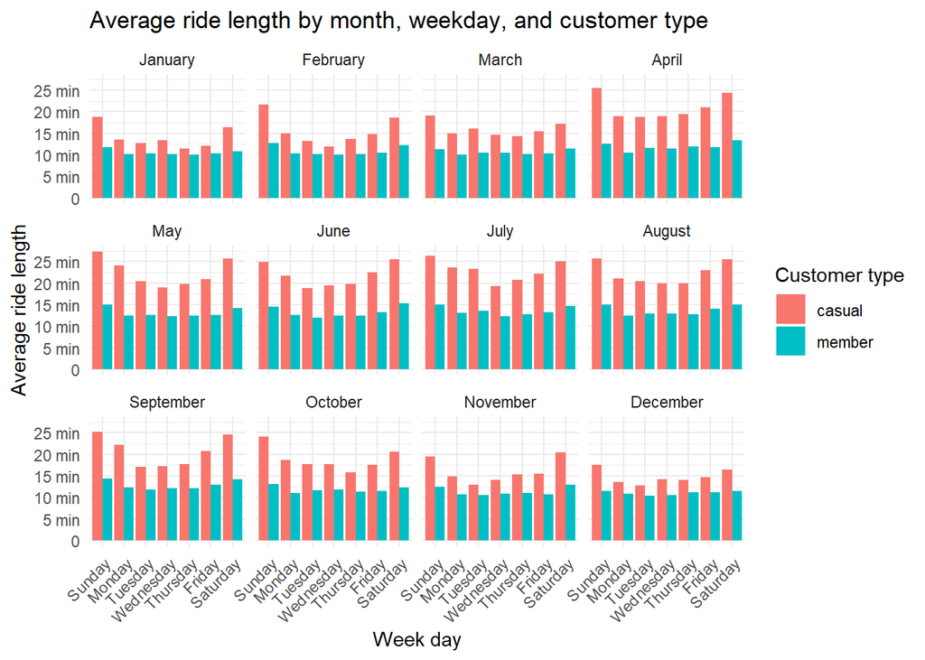

```r
#Variables
y_breaks <- seq(0, 1800, by = 300)
y_labels <-c ("0", "5 min", "10 min", "15 min", "20 min", "25 min", "30 min")


#Creating facet-plots to visualize data for each month
#Average ride length by month, weekday, and customer type
plot_1_01 <- ggplot(bike_avg_ride_length, aes(x = day_of_week, y = avg_ride_length, fill = member_casual)) +
  geom_bar(stat = "identity", position = "dodge") +
  scale_y_continuous(breaks = y_breaks, labels = y_labels) +
  labs(x = "Week day", y = "Average ride length", fill = "Customer type", title = "Average ride length by month, weekday, and customer type") +
  facet_wrap(~month, scales = "fixed") +
  theme_minimal() +
  theme(axis.text.x = element_text(angle = 45, hjust = 1))

print(plot_1_01)
```

```r
ggsave("plot-1-01.png", plot = plot_1_01, width = 10, height = 6)
```

From this chart, it’s clear that on weekdays, the average ride length for Members consistently falls within the range of 10 to 12.5 minutes. However, there are occasional spikes beyond the 12.5-minute threshold on select weekdays from May to September. Interestingly, Members’ ride lengths remain relatively consistent throughout the year, regardless of the season. On the other hand, Casual riders show an increase in trip duration during warmer months.

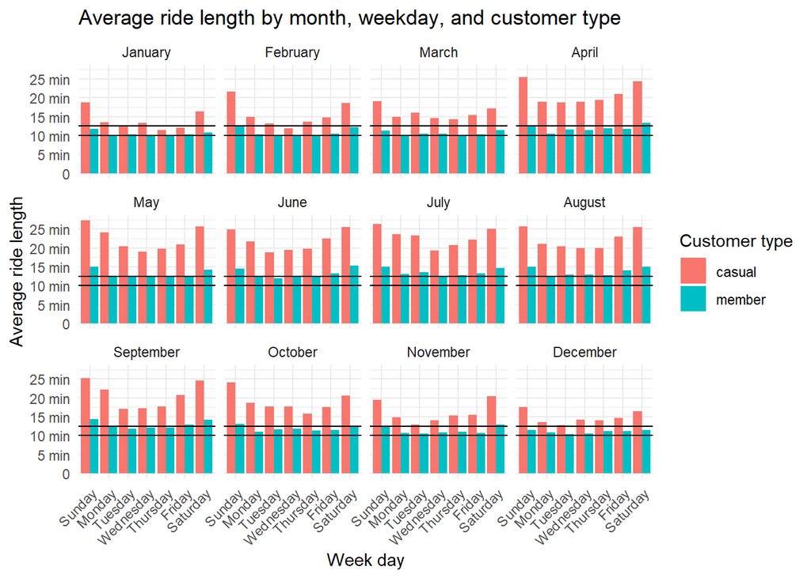

```r
#Adding two horisontal lines to plot to increace readability
plot_1_02 <- ggplot(bike_avg_ride_length, aes(x = day_of_week, y = avg_ride_length, fill = member_casual)) +
  geom_bar(stat = "identity", position = "dodge") +
  scale_y_continuous(breaks = y_breaks, labels = y_labels) +
  labs(x = "Week day", y = "Average ride length", fill = "Customer type", title = "Average ride length by month, weekday, and customer type") +
  facet_wrap(~month, scales = "fixed") +
  theme_minimal() +
  theme(axis.text.x = element_text(angle = 45, hjust = 1)) +
  geom_hline(yintercept = 600, color = "black", linetype = "solid", linewidth = 0.5) +
  geom_hline(yintercept = 750, color = "black", linetype = "solid", linewidth = 0.5)

print(plot_1_02)
```

```r
ggsave("plot-1-02.png", plot = plot_1_02, width = 10, height = 6)
```

#### 5.1.2 Average ride length by month and customer type

This graph illustrates the average ride length during different months, categorized by the type of member (casual or member). Each bar represents a specific month, and the height of the bar corresponds to the average ride length for that month.

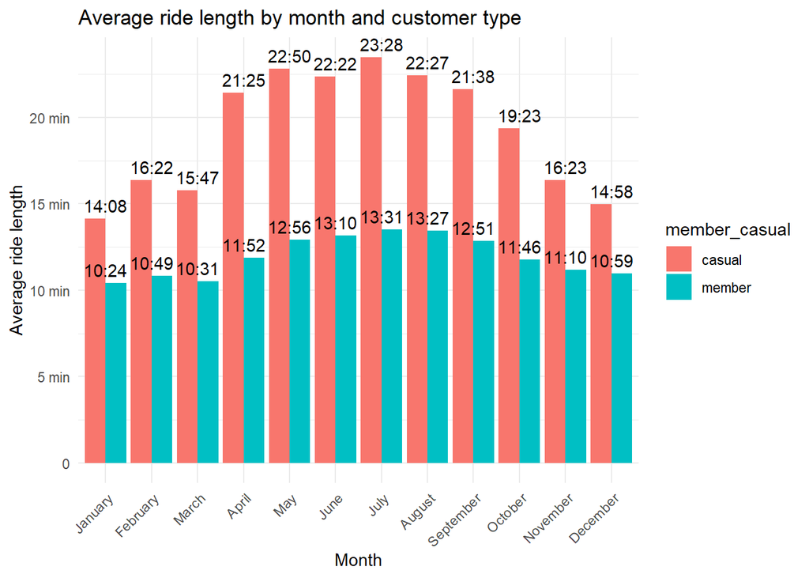

```r
#Variables
y_breaks <- seq(0, 1800, by = 300)
y_labels <-c ("0", "5 min", "10 min", "15 min", "20 min", "25 min", "30 min")

#Average ride length by month and customer type
plot_1_03 <- ggplot(bike_avg_ride_length_month, aes(x = month, y = avg_ride_length_month, fill = member_casual)) +
  geom_bar(stat = "identity", position = "dodge") +
  scale_y_continuous(breaks = y_breaks, labels = y_labels) +
  geom_text(aes(label = ride_length_min_sec), vjust = -0.5) +
  labs(x = "Month", y = "Average ride length", title = "Average ride length by month and customer type") +
  theme_minimal() +
  theme(axis.text.x = element_text(angle = 45, hjust = 1))

print(plot_1_03)
```

```r
ggsave("plot-1-03.png", plot = plot_1_03, width = 10, height = 6)
```

In conclusion, this chart reinforces the observation of an increase in the average ride length during warmer months. Additionally, it highlights that the range of ride length variation for Member riders remains within a 5-minute span, whereas for Casual riders, it’s approximately 10 minutes.

#### 5.1.3 Average ride length by weekday and customer type

This graph presents the yearly summary of average ride length during weekdays. It provides an overview of the average ride length across all months aggregated into a single plot. Similar to the monthly graph, the x-axis represents the days of the week, the y-axis represents the average ride length, and bars are colored based on the type of member.

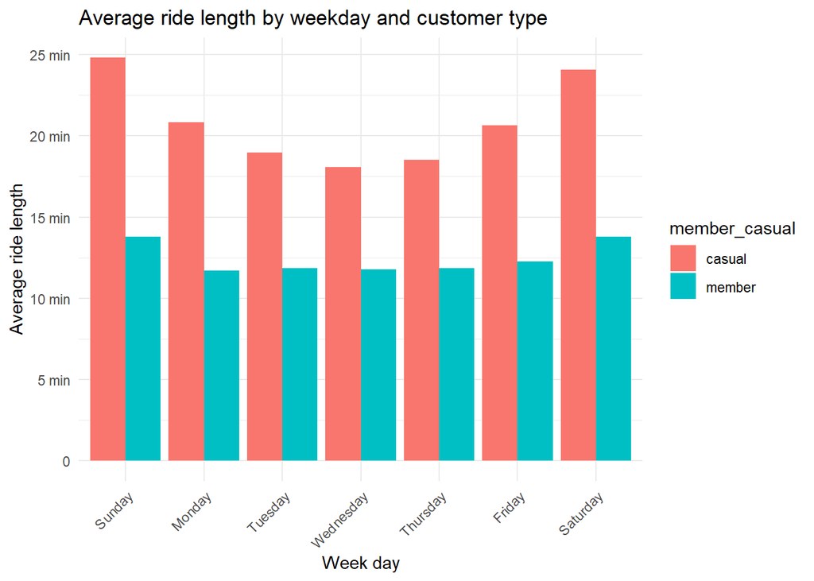

```r
#Variables
y_breaks <- seq(0, 1800, by = 300)
y_labels <-c ("0", "5 min", "10 min", "15 min", "20 min", "25 min", "30 min")

plot_1_04 <- ggplot(bike_avg_ride_length_week, aes(x = day_of_week, y = avg_ride_length_week, fill = member_casual)) +
  geom_bar(stat = "identity", position = "dodge") +
  scale_y_continuous(breaks = y_breaks, labels = y_labels) +
  labs(x = "Week day", y = "Average ride length", title = "Average ride length by weekday and customer type") +
  theme_minimal() +
  theme(axis.text.x = element_text(angle = 45, hjust = 1))

print(plot_1_04)
```

```r
ggsave("plot-1-04.png", plot = plot_1_04, width = 10, height = 6)
```

The trends in data distribution for Casual and Member riders are similar. Both groups tend to have longer ride lengths on weekends. However, Casual riders demonstrate more variability between data points throughout the week, whereas Members’ ride lengths remain more consistent.

#### 5.1.4 Average ride length by customer type

This graph visualizes the average ride length for different customer types (casual and member). Each bar represents a customer type, and the height of the bar corresponds to the average ride length. Bars are colored based on the customer type.

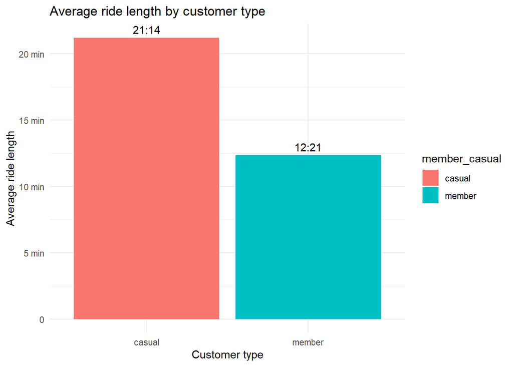

```r
#Variables
y_breaks <- seq(0, 1800, by = 300)
y_labels <-c ("0", "5 min", "10 min", "15 min", "20 min", "25 min", "30 min")

#Average ride length by customer type
plot_1_05 <- ggplot(bike_avg_ride_length_member_type, aes(x = member_casual, y = avg_ride_length_member_type, fill = member_casual)) +
  geom_bar(stat = "identity", position = "dodge") +
  geom_text(aes(label = ride_length_min_sec), vjust = -0.5) +
  scale_y_continuous(breaks = y_breaks, labels = y_labels) +
  labs(x = "Customer type", y = "Average ride length", title = "Average ride length by customer type") +
  theme_minimal()

print(plot_1_05)
```

```r
ggsave("plot-1-05.png", plot = plot_1_05, width = 10, height = 6)
```

### 5.2 Ride count

#### 5.2.1 Ride count by month, weekday, and customer type

This graph visualizes the ride counts by day of the week across different months, categorized by by customer type (casual or member). Each subplot represents a month, showing the distribution of ride counts by day of the week. The x-axis represents the days of the week, while the y-axis represents the total ride count. Bars are colored based on the type of member.

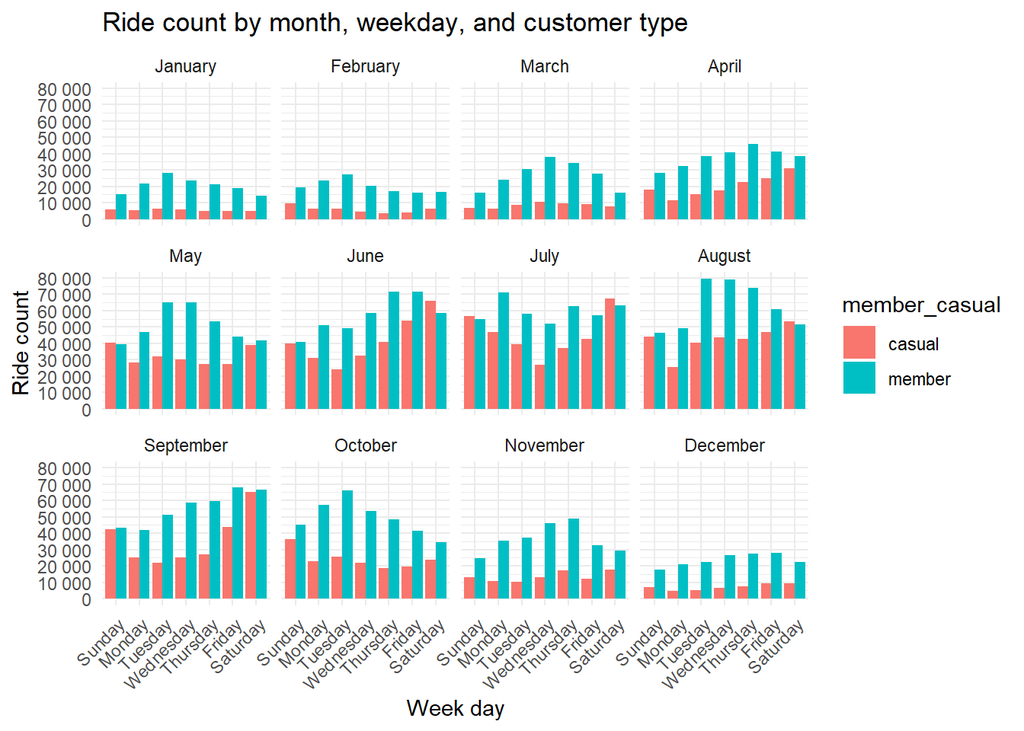

```r
#Variables
y_breaks <- seq(0, 80000, by = 10000)
y_labels <-c ("0", "10 000", "20 000", "30 000", "40 000", "50 000", "60 000", "70 000", "80 000")

#Ride count by month, weekday, and customer type
plot_2_06 <- ggplot(bike_ride_count, aes(x = day_of_week, y = ride_count, fill = member_casual)) +
  geom_bar(stat = "identity", position = "dodge") +
  scale_y_continuous(breaks = y_breaks, labels = y_labels) +
  labs(x = "Week day", y = "Ride count", title = "Ride count by month, weekday, and customer type") +
  facet_wrap(~month, scales = "fixed") +
  theme_minimal() +
  theme(axis.text.x = element_text(angle = 45, hjust = 1))

print(plot_2_06)
```

```r
ggsave("plot-2-06.png", plot = plot_2_06, width = 10, height = 6)
```

Visualizing data for each month provides a quick grasp of trends:

Members take more rides than Casual riders.

Both groups tend to take more rides from late spring through fall.

My attention was caught by August, particularly by a significant leap in ride count numbers for Member riders between Monday and Tuesday, and a notable decline in ride counts on Mondays for Casual riders. High numbers in ride counts between Monday and Friday are normal for Member riders, and August emerges as the most popular month for subscribed customers overall. Moreover, Members almost always display higher numbers on Mondays compared to Sundays. I suspect that something triggered a decline in ride counts for both groups on Mondays in August, which accentuated the difference in bar heights for Monday and Tuesday.

I plan to examine August more closely after running a few more visualizations.

#### 5.2.2 Ride count by month and customer type

This chart illustrates the distribution of ride counts across different months, categorized by customer type (casual or member). Each bar represents the total number of rides taken during a specific month. The y-axis denotes the ride count, while the x-axis displays the months of the year.

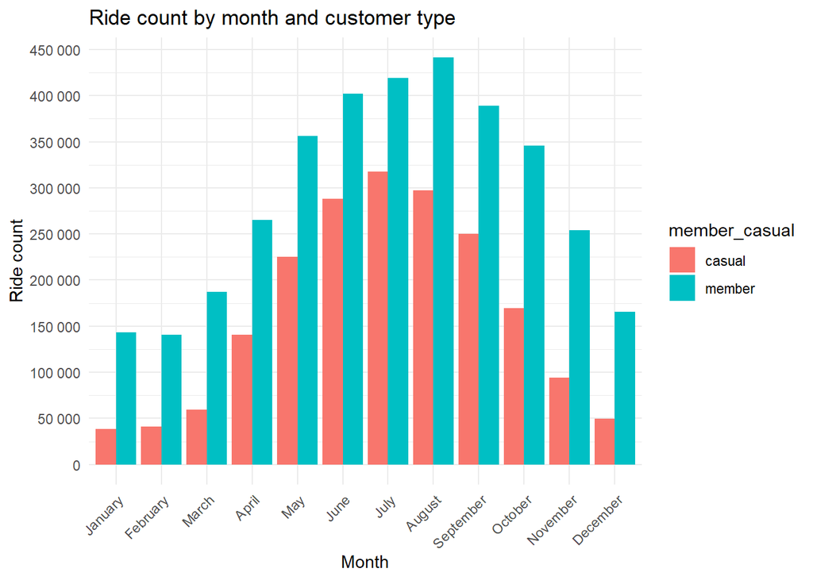

```r
#Variables
y_breaks <- seq(0, 450000, by = 50000)
y_labels <-c ("0", "50 000", "100 000", "150 000", "200 000", "250 000", "300 000", "350 000", "400 000", "450 000")

#Ride count by month and customer type
plot_2_07 <- ggplot(bike_ride_count_month, aes(x = month, y = ride_count_month, fill = member_casual)) +
  geom_bar(stat = "identity", position = "dodge") +
  scale_y_continuous(breaks = y_breaks, labels = y_labels) +
  labs(x = "Month", y = "Ride count", title = "Ride count by month and customer type") +
  theme_minimal() +
  theme(axis.text.x = element_text(angle = 45, hjust = 1))

print(plot_2_07)
```

```r
ggsave("plot-2-07.png", plot = plot_2_07, width = 10, height = 6)
```

Both casual and member riders rent bicycles more frequently during the warmer seasons. To prevent errors and enhance readability for this data, I’ve decided to add two more charts to this section.

##### 5.2.2.1 Top month by ride count and customer type

The plots depict the distribution of ride counts among two distinct groups of riders: member riders and casual riders. Each bar represents the total number of rides taken by riders within specific months. The x-axis denotes the months, while the y-axis quantifies the ride count.

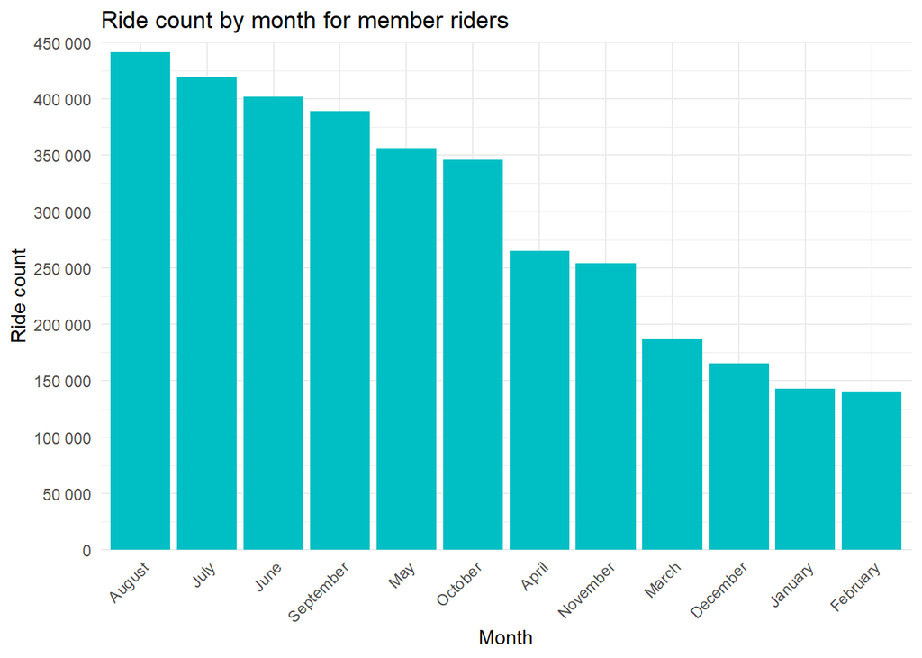

```r
#Variables
y_breaks <- seq(0, 450000, by = 50000)
y_labels <-c ("0", "50 000", "100 000", "150 000", "200 000", "250 000", "300 000", "350 000", "400 000", "450 000")

ordered_ride_count_month_member$month <- factor(ordered_ride_count_month_member$month, levels = ordered_ride_count_month_member$month[order(-ordered_ride_count_month_member$ride_count_month)])

ordered_ride_count_month_casual$month <- factor(ordered_ride_count_month_casual$month, levels = ordered_ride_count_month_casual$month[order(-ordered_ride_count_month_casual$ride_count_month)])

#Top Month by ride count for casual riders
plot_2_08 <- ggplot(ordered_ride_count_month_member, aes(x = month, y = ride_count_month)) +
  geom_bar(stat = "identity", fill = "#00BFC4") +
  scale_y_continuous(limits = c(0, 450000), breaks = y_breaks, labels = y_labels, expand = c(0, 0)) +
  labs(x = "Month", y = "Ride count", title = "Ride count by month for member riders") +
  theme_minimal() +
  theme(axis.text.x = element_text(angle = 45, hjust = 1))

print(plot_2_08)
```

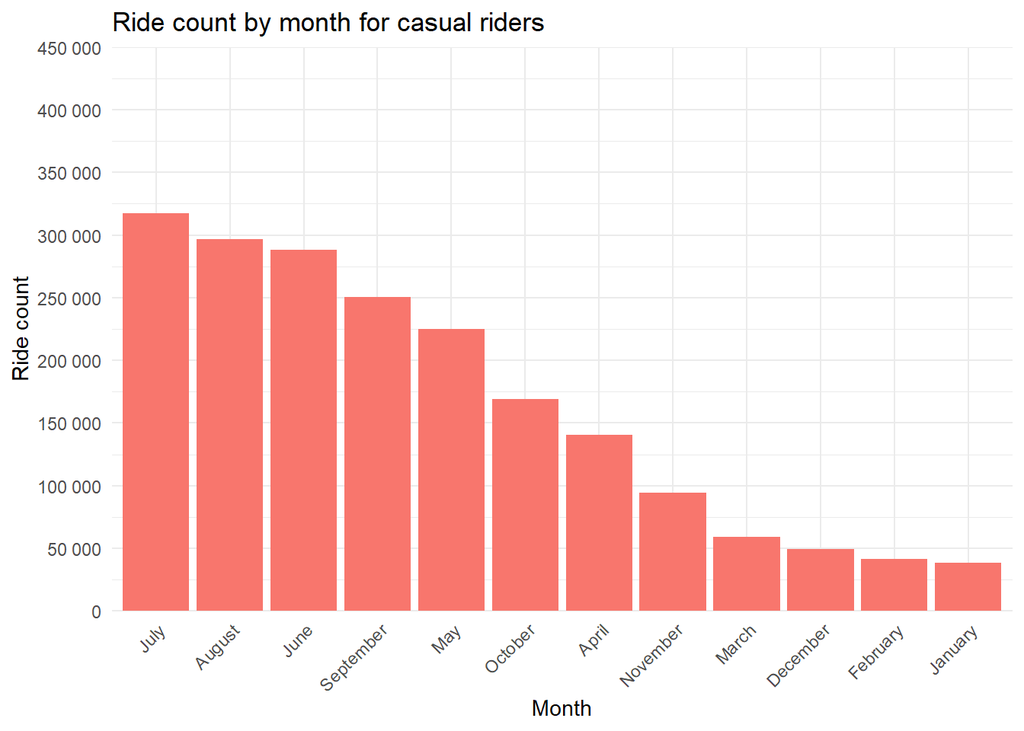

```r
ggsave("plot-2-08.png", plot = plot_2_08, width = 10, height = 6)

#Top Month by ride count for casual riders
plot_2_09 <- ggplot(ordered_ride_count_month_casual, aes(x = month, y = ride_count_month)) +
  geom_bar(stat = "identity", fill = "#F8766D") +
  scale_y_continuous(limits = c(0, 450000), breaks = y_breaks, labels = y_labels, expand = c(0, 0)) +
  labs(x = "Month", y = "Ride count", title = "Ride count by month for casual riders") +
  theme_minimal() +
  theme(axis.text.x = element_text(angle = 45, hjust = 1))

print(plot_2_09)
```

```r
ggsave("plot-2-09.png", plot = plot_2_09, width = 10, height = 6)
```

These charts further demonstrate the similarity in ride count distribution among different months. When comparing these charts, only the first and last two months change their order, while the order of months in the middle remains the same.

*To ensure a fair representation of the data, I aimed for both charts to share the same Y-axis values. Without manually setting the Y-axis limit, the division proportions appeared differently on each graph. This discrepancy could potentially create a false impression that the ride counts for both customer types are similar. Despite specifying ‘breaks =’, it was insufficient to resolve the issue with the Y-axis in these charts.

#### 5.2.3 Ride count by weekday and customer type

This graph displays the distribution of ride counts by day of the week. Bars are grouped by the type of customer (casual or member).

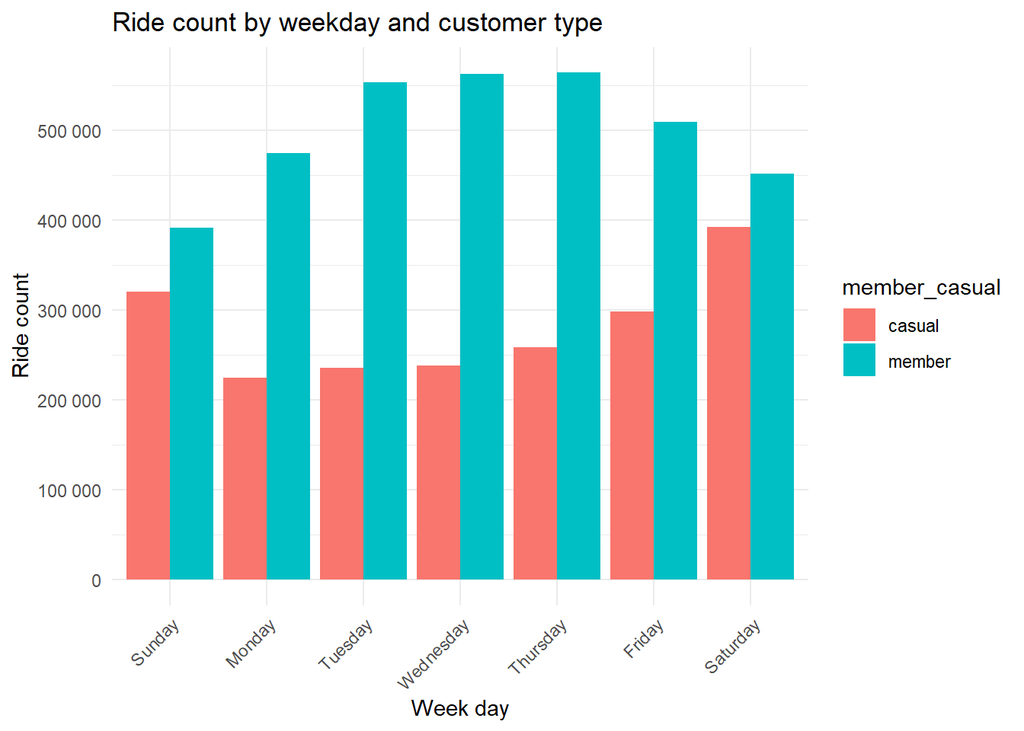

```r
#Variables
y_breaks <- seq(0, 600000, by = 100000)
y_labels <-c ("0", "100 000", "200 000", "300 000", "400 000", "500 000", "600 000")

#Ride Count by weekday and customer type
plot_2_10<- ggplot(bike_ride_count_week, aes(x = day_of_week, y = ride_count_week, fill = member_casual)) +
  geom_bar(stat = "identity", position = "dodge") +
  scale_y_continuous(breaks = y_breaks, labels = y_labels) +
  labs(x = "Week day", y = "Ride count", title = "Ride count by weekday and customer type") +
  theme_minimal() +
  theme(axis.text.x = element_text(angle = 45, hjust = 1))

print(plot_2_10)
```

```r
ggsave("plot-2-10.png", plot = plot_2_10, width = 10, height = 6)
```

These charts illustrate the key difference between Casual and Member riders:

Member riders ride more on workdays. Days with highest ride counts are Thursday (564 693), Wednesday (562 609) and Tuesday (553 433). Casual riders ride more on weekends. Days with highest ride counts are Saturday (392 349), Sunday (320 498) and Friday (298 460).

#### 5.2.4 Ride count by hour, weekday and customer type

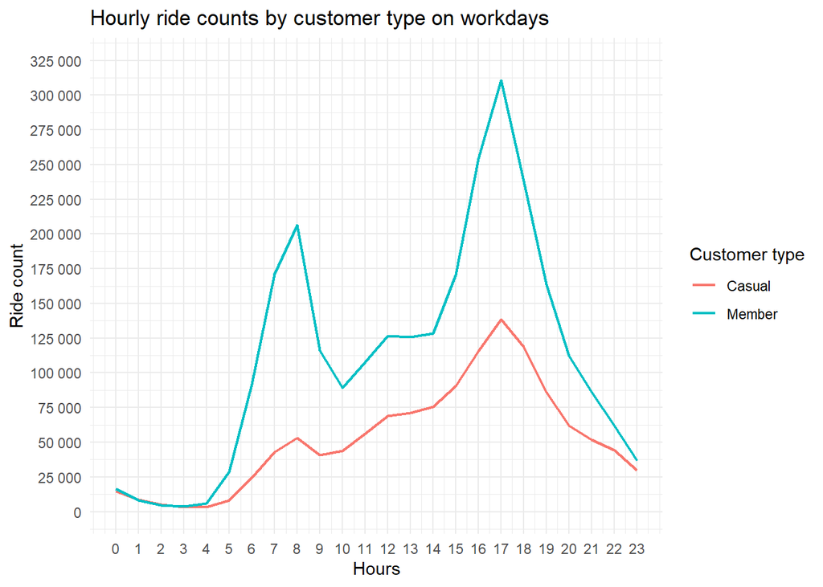

```r
#Variables
y_breaks <- seq(0, 325000, by = 25000)
y_labels <- c("0", "25 000", "50 000", "75 000", "100 000", "125 000", "150 000", "175 000", "200 000", "225 000", "250 000", "275 000", "300 000", "325 000")

#Hourly ride counts by customer type on workdays
plot_2_11 <- ggplot() +
  geom_line(aes(x = start_hour, y = ride_count, colour = "Casual"), size = 0.8, data = rides_by_hour_workdays_casual) +
  geom_line(aes(x = start_hour, y = ride_count, colour = "Member"), size = 0.8, data = rides_by_hour_workdays_member) +
  scale_x_continuous(breaks = 0:23) +
  scale_y_continuous(limits = c(0, 325000), breaks = y_breaks, labels = y_labels) +
  labs(title = "Hourly ride counts by customer type on workdays", x = "Hours", y = "Ride count",) +
  scale_color_manual(values = c("#F8766D", "#00BFC4"), labels = c("Casual", "Member"), name = "Customer type") +
  theme_minimal()
print(plot_2_11)
```

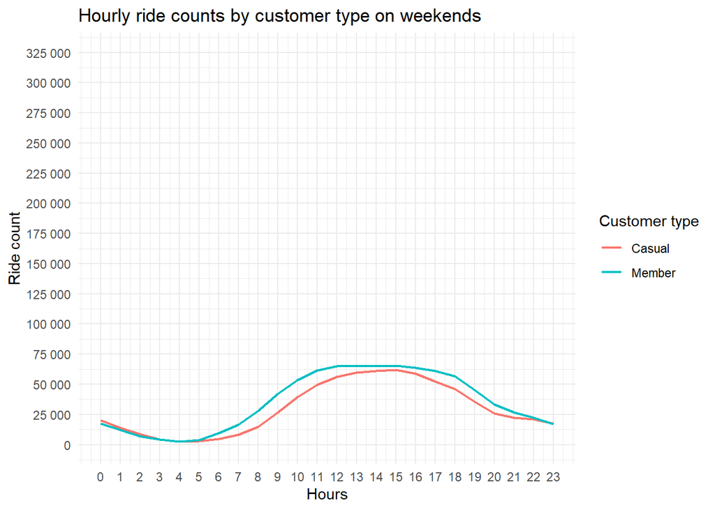

```r
ggsave("plot-2-11.png", plot = plot_2_11, width = 10, height = 6)

#Hourly ride counts by customer type on workdays
plot_2_12 <- ggplot() +
  geom_line(aes(x = start_hour, y = ride_count, colour = "Casual"), size = 0.8, data = rides_by_hour_weekends_casual) +
  geom_line(aes(x = start_hour, y = ride_count, colour = "Member"), size = 0.8, data = rides_by_hour_weekends_member) +
  scale_x_continuous(breaks = 0:23) +
  scale_y_continuous(limits = c(0, 325000), breaks = y_breaks, labels = y_labels) +
  labs(title = "Hourly ride counts by customer type on weekends", x = "Hours", y = "Ride count",) +
  scale_color_manual(values = c("#F8766D", "#00BFC4"), labels = c("Casual", "Member"), name = "Customer type") +
  theme_minimal()

print(plot_2_12)
```

```r
ggsave("plot-2-12.png", plot = plot_2_12, width = 10, height = 6)
```

There are two notable peaks in ride count during workdays for both groups:

8:00 Member riders: 206 460 rides Casual riders: 52 924 rides

17:00 Member riders: 310 870 rides Casual riders: 138 470 rides

These peaks align with Chicago’s rush hour schedule. According to a [source](https://www.rosenfeldinjurylawyers.com/news/rush-hour-chicago/#:~:text=Traffic%20tends%20to%20be%20the,sports%20venues%20during%20game%20days.), ‘Traffic tends to be the worst around 6 AM to 8 AM and between 4 PM and 6 PM. Traffic jams are constant on Illinois expressways, with people trying to get in and out of the city.’

At 16:00, Member riders will surpass their 8:00 ride count peak by 47 883 rides. Casual riders will have a total of 115 628 rides, which is 62 704 rides (a 118% increase) more than at 8:00.

Trends during the weekend are also similar for Casual and Member riders, with ride counts peaking at 15:00 for both groups:

Member riders: 65 592 rides Casual riders: 61 883 rides.

#### 5.2.5 Ride count by customer type

This graph presents the distribution of ride counts for different customer types (casual and member). Each segment represents a customer type, and the height of the bar indicates the total number of rides. Bars are colored based on the customer type.

This pie chart visualizes the distribution of ride counts by customer type. Each segment of the pie represents a different customer type (member or casual), with the size of the segment indicating the proportion of rides attributed to each customer type. The chart provides a comparison of ride counts between member and casual customers.

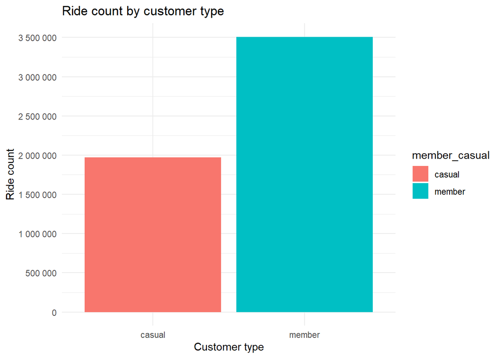

```r
#Variables
y_breaks <- seq(0, 3500000, by = 500000)
y_labels <-c ("0", "500 000", "1 000 000", "1 500 000", "2 000 000", "2 500 000", "3 000 000", "3 500 000")

#Bar chart: Ride count by customer type
plot_2_13 <- ggplot(bike_ride_count_member_type, aes(x = member_casual, y = ride_count_member_type, fill = member_casual)) +
  geom_bar(stat = "identity", position = "dodge") +
  scale_y_continuous(breaks = y_breaks, labels = y_labels) +
  labs(x = "Customer type", y = "Ride count", title = "Ride count by customer type") +
  theme_minimal()

print(plot_2_13)
```

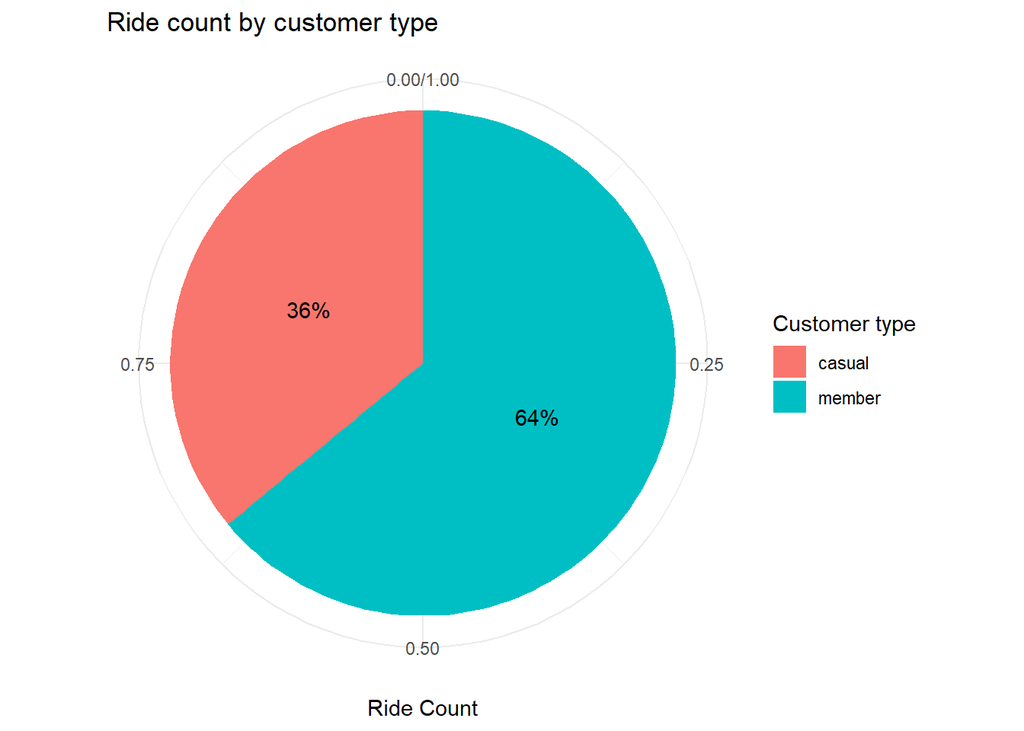

```r
ggsave("plot-2-13.png", plot = plot_2_13, width = 10, height = 6)

#Palette
color_palette <- c("#F8766D", "#00BFC4")

#Pie chart: Ride count by customer type
plot_2_14 <- ggplot(bike_ride_count_member_type, aes(x = "", y = percentages_ride_count_member_type, fill = member_casual)) +
  geom_col() +
  geom_text(aes(label = labels_ride_count_member_type_perc),
            position = position_stack(vjust = 0.5)) +
  coord_polar(theta = "y") +
  scale_fill_manual(values = color_palette) +
  theme_minimal() +
  labs(x = NULL, y = "Ride Count",
       fill = "Customer type", title = "Ride count by customer type")

print(plot_2_14)
```

```r
ggsave("plot-2-14.png", plot = plot_2_14, width = 10, height = 6)
```

Members enjoy nearly twice as many rides as casual riders, with a total ride count of 3 508 685 compared to 1 970 110 for Casual riders.

### 5.3 Investigating August

My attention was caught by a significant leap in ride count numbers for Member riders between Monday and Tuesday, and a notable decline in ride counts on Mondays for Casual riders.

High numbers in ride counts between Monday and Friday are normal for Member riders, and August emerges as the most popular month for subscribed customers overall. Moreover, Members almost always display higher numbers on Mondays compared to Sundays. I suspect that something triggered a decline in ride counts for both groups on Mondays in August, which accentuated the difference in bar heights for Monday and Tuesday.

Let’s filter out the data for August and examine it. Additionally, let’s try to identify the root cause for this decline.

```r
#Filtering August
august_member_casual <- bike_data_2023 %>%
  filter(month == "August") %>%
  mutate(date = as.Date(started_at))

#print(august_member_casual)

#August ride count for casual riders
#Checking which monday had least ride counts for casuals in August
august_casual_grouped <- august_member_casual %>%
  filter(member_casual == "casual") %>%
  group_by(date) %>%
  summarise(ride_count = n())

#print(august_casual_grouped)

#August ride count for member riders
august_member_grouped <- august_member_casual %>%
  filter(member_casual == "member") %>%
  group_by(date) %>%
  summarise(ride_count = n())

#print(august_member_grouped)
```

Events? I desided to explore what events could trigger data spikes by looking what [festivals](https://freetoursbyfoot.com/things-to-do-august-chicago/) took place during August.

Several festivals and events occurred during August. These events include music festivals like the Jefferson Park Arts & Music Festival and Northalsted Market Days, food and drink festivals such as Taste of Chicago and Ribfest, neighborhood festivals like Edison Park Fest and Ginza Holiday Festival, and arts festivals like the Glenwood Avenue Arts Festival.

Given that all these events occurred on weekends, it is improbable that they contributed to the decrease in ride counts on Mondays.

Weather?

According to the [Chicago weather forecast](https://world-weather.info/forecast/usa/chicago/august-2023/), there was a storm on both Monday the 14th and Saturday the 5th. The bad weather on Monday led to a decrease in ride counts for both rider groups as riders opted for alternative transportation options.

These visualizations depict the ride count trends for both casual and member riders throughout August. Each graph illustrates the distribution of ride counts across different dates, with the x-axis indicating the date and the y-axis representing the total ride count. Bars are color-coded to distinguish between casual and member riders.

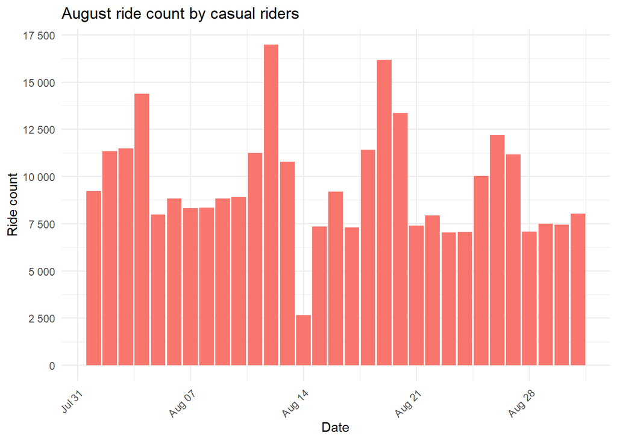

```r
#Variables
y_breaks <- seq(0, 20000, by = 2500)
y_labels <-c ("0", "2 500", "5 000", "7 500", "10 000", "12 500", "15 000", "17 500", "20 000")

#August ride count by casual riders
plot_3_15 = ggplot(august_casual_grouped, aes(x = date, y = ride_count)) +
  geom_bar(stat = "identity", fill = "#F8766D") +
  scale_y_continuous(breaks = y_breaks, labels = y_labels) +
  labs(x = "Date", y = "Ride count", title = "August ride count by casual riders") +
  theme_minimal() +
  theme(axis.text.x = element_text(angle = 45, hjust = 1))

print(plot_3_15)
```

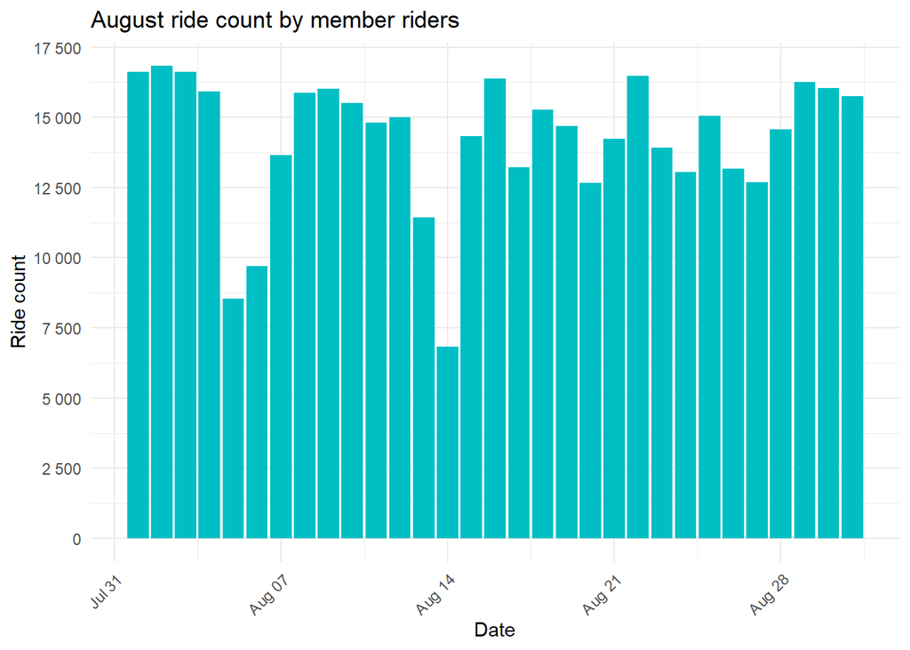

```r
ggsave("plot-3-15.png", plot = plot_3_15, width = 10, height = 6)

#August ride count by member riders
plot_3_16 = ggplot(august_member_grouped, aes(x = date, y = ride_count)) +
  geom_bar(stat = "identity", fill = "#00BFC4") +
  scale_y_continuous(breaks = y_breaks, labels = y_labels) +
  labs(x = "Date", y = "Ride count", title = "August ride count by member riders") +
  theme_minimal() +
  theme(axis.text.x = element_text(angle = 45, hjust = 1))

print(plot_3_16)
```

```r
ggsave("plot-3-16.png", plot = plot_3_16, width = 10, height = 6)
```

The quick visualization of August daily ride counts indeed suggests that weather is likely to blame for the fluctuations.

For Member riders, the two days with the lowest ride counts in August were Monday the 14th (6 830 ride counts) and Saturday the 5th (8 535 ride counts), both days with storms.

Similarly, the ride counts for Casual riders were also impacted by storms on both Monday the 14th (2 656 ride counts) and Saturday the 5th (7 989 ride counts). The bar for Saturday the 5th is nearly half as small as the usual peaks observed on Saturdays for the Casual rider group.

These charts once more highlight the consistent riding patterns of Members compared to Casual riders.

### 5.4 Distribution of rideable types by customer type

This pie chart visualizes the distribution of rideable types utilized by customers of Cyclistic bike-sharing service, categorized by customer type (casual and member). Each segment of the pie chart represents a combination of customer type and rideable type, indicating the proportion of rides associated with that combination.

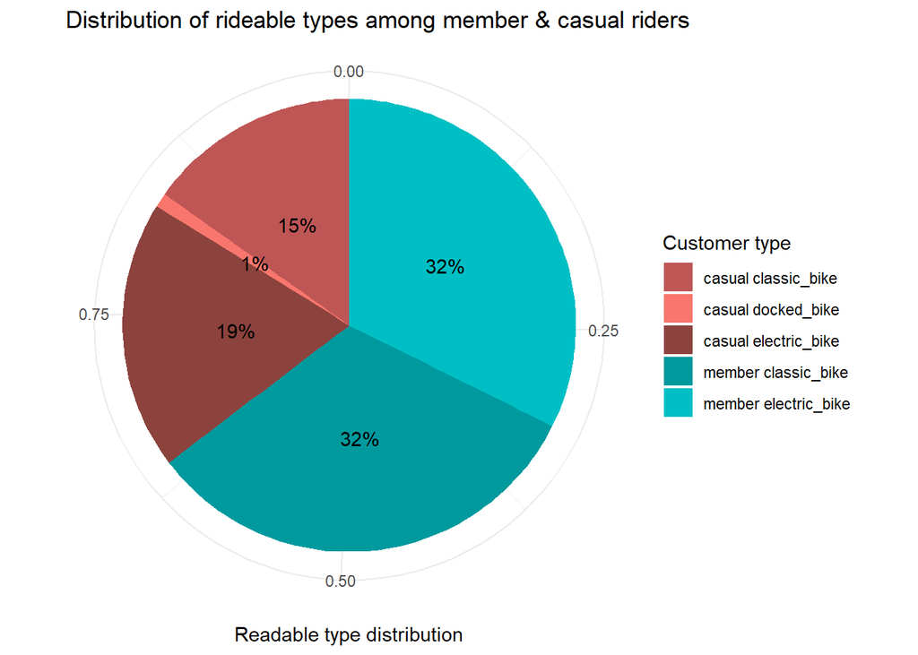

```r
color_palette <- c("#BF5656","#F8766D", "#8C433E", "#009A9E", "#00BFC4")

plot_4_17 <- ggplot(rideable_summary, aes(x = "", y = percentages_rideable_type, fill = lab_name)) +
  geom_col() +
  geom_text(aes(label = labels_rideable_type_perc),
            position = position_stack(vjust = 0.5)) +
  coord_polar(theta = "y") +
  scale_fill_manual(values = color_palette) +
  theme_minimal() +
  labs(x = NULL, y = "Readable type distribution",
       fill = "Customer type", title = "Distribution of rideable types among member & casual riders")

print(plot_4_17)
```

```r
ggsave("plot-4-17.png", plot = plot_4_17, width = 10, height = 6)
```

Members equally prefer classic and electric bikes. However, according to the data, Casual riders tend to ride electric bikes slightly more frequently compared to classic bikes. It’s also worth noting that only Casual riders used docked bikes in 2023.

### 5.6 Top 15 Most popular stations by ride count

This bar graph illustrates the top 15 stations ranked by the number of rides initiated from each station. Each bar represents a station, with the height indicating the total ride count. Stations are ordered from top to bottom based on their ride count, with the station boasting the highest number of rides positioned at the top. The x-axis displays the ride count, while the y-axis denotes the station names.

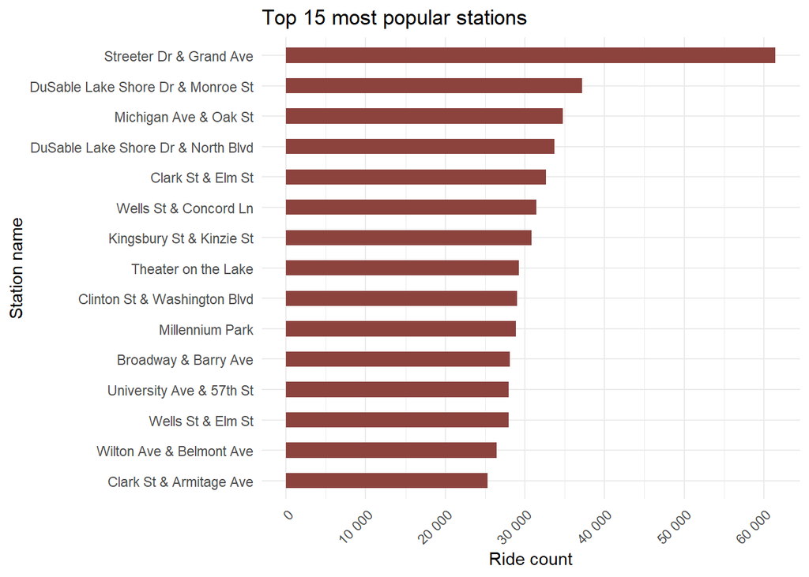

```r
#Variables
y_breaks <- seq(0, 65000, by = 5000)
y_labels <-c ("0", "5 000", "10 000", "15 000", "20 000", "25 000", "30 000", "35 000", "40 000", "45 000", "50 000", "55 000", "60 000", "65 000")


#Variables
y_breaks <- seq(0, 70000, by = 10000)
y_labels <-c ("0", "10 000", "20 000", "30 000", "40 000", "50 000", "60 000", "70 000")
#Ordering Stations
ordered_station_top <- transform(station_top, start_station_name = factor(start_station_name, levels = station_top$start_station_name[order(station_top$ride_count, decreasing = TRUE)]))
ordered_station_top$start_station_name <- fct_reorder(station_top$start_station_name, station_top$ride_count, .desc = FALSE)

##Top 15 popular stations
plot_5_18 <- ggplot(ordered_station_top, aes(x = ride_count, y = start_station_name)) +
  geom_bar(stat = "identity", fill = "#8C433E", width = 0.5) +
  scale_x_continuous(breaks = y_breaks, labels = y_labels) +
  labs(y = "Station name", x = "Ride count", title = "Top 15 most popular stations") +
  theme_minimal() +
  theme(axis.text.x = element_text(angle = 45, hjust = 1))

print(plot_5_18)
```

```r
ggsave("plot-5-18.png", plot = plot_5_18, width = 10, height = 6)
```

1. Streeter Dr & Grand Ave - 61 472
2. DuSable Lake Shore Dr & Monroe St - 37 210

30 000 - 35 000 03. Michigan Ave & Oak St 04. DuSable Lake Shore Dr & North Blvd 05. Clark St & Elm St 06. Wells St & Concord Ln 07. Kingsbury St & Kinzie St

25 000 - 30 000 08. Theater on the Lake 09. Clinton St & Washington Blvd 10. Millennium Park 11. Broadway & Barry Ave 12. University Ave & 57th St 13. Wells St & Elm St 14. Wilton Ave & Belmont Ave 15. Clark St & Armitage Ave

### ANALYSIS SUMMARY

**How do annual members and casual riders use Cyclistic bikes differently?**

The difference in ride frequency between annual members and casual riders can be attributed to the distinct payment structures they operate under.

Annual members, benefiting from an unlimited pass, are able to take advantage of the bikes without incurring additional costs per ride. This unrestricted access encourages them to utilize the bikes more frequently, incorporating them into various aspects of their daily routines.

Conversely, casual riders, who are charged for each trip, approach bike usage with a more selective mindset. They may reserve their rides for specific occasions or longer journeys where they can maximize the value of each paid trip.

Overall, annual members and casual riders demonstrate different usage patterns, with annual members using Cyclistic bikes more frequently for commuting or short trips, while casual riders tend to use them for longer, leisurely rides, especially during weekends and warmer months.

*The data for Casual riders did not include information about whether they purchased a single pass or a full-day pass. Collecting this data will provide further insights into differences between Cyclistic riders.

## 6. ACT

With the insights gathered from analyzing Cyclistic customer behaviors, the marketing team devised an effective strategy to encourage more casual riders to become full-time Cyclistic members.

## Commentary

This project has changed my opinion about R. Initially, I wanted to conduct my analysis using SQL, but I quickly ran out of free space on my BigQuery account, so I decided to go with R instead. Surprisingly, I really enjoyed the whole process, despite R being my least favorite module to complete in the Google Data Analytics course. The Capstone project helped me get used to the interface and writing comments. The document structure that comes with the RMD format really helps keep the workspace organized and allows quick navigation between different sections. Apart from deriving insights from the data, I strived to maintain consistency in both my documentation and code throughout this analysis. This ensures clear and coherent presentation of results, but also promotes organized workflow for future reference.

*Version 002* *Reconsider scale values for some charts.*

```r
write.csv(bike_data_2023, "bike_data_2023.csv", row.names = FALSE)
```